# Realm of Racket: Learn to Program, One Game at a Time!

### Neighbors

The definition of `attacks`, within `game-tree`, requires us to implement two functions: `neighbors` and `attackable?`. The `neighbors` function consumes the unique index of a `territory` and returns a list of indices for the territories that border it. This function gets a little tricky because there are two kinds of hexagons we need to worry about here: the ones on even rows and the ones on odd rows. In order to get the hexagons to fit together, we shift every other row to the left. Accordingly, there are two kinds of calculations needed or, actually, one calculation adjusted for the shift in rows.

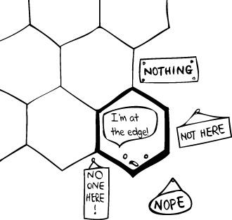

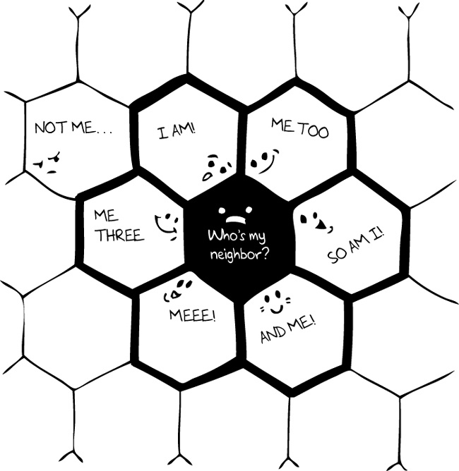

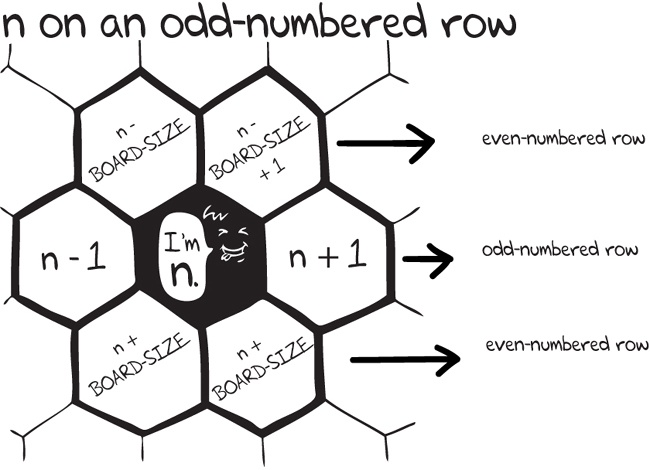

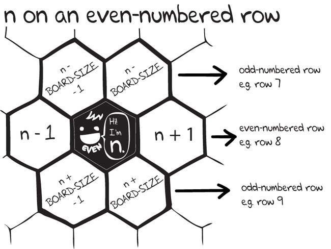

Every hexagon has maximally six neighbors: two above, two below, and one on either side. Pictorially, the calculations proceed according to the diagrams in Neighbors. But there is one more thing to consider. If a hexagon borders any of the four edges, it doesn’t have neighbors on some sides, so the math shown will return meaningless results.

Now let’s think about how the `neighbors` function might create the list of indicies. If it weren’t for border cases, the function would produce a list of six numbers. Hence, this looks like a good first sketch:

```
(define (neighbors n)
  (list  upper-right
         bottom-right
         upper-left
         lower-left
         right
         left))
```

As discussed earlier, some of these numbers are added only when certain conditions hold. An easy way to choose whether or not to add something to a list is to define another function:

```
(define (add b x)
  (if b empty (list x)))
```

It takes a Boolean and a value and returns either the `empty` list or the list with just that value. Using `add`, you can then append as many of these values together as you wish, and the resulting list contains just the right number of elements.

At this point, our `neighbors` function becomes fairly straightforward:

```
(define (neighbors pos)
  (define top?      (< pos BOARD))
  (define bottom?   (= (get-row pos) (sub1 BOARD)))
  (define even-row? (zero? (modulo (get-row pos) 2)))
  (define right?    (zero? (modulo (add1 pos) BOARD)))
  (define left?     (zero? (modulo pos BOARD)))
  (if even-row?
      (even-row pos top? bottom? right? left?)
      (odd-row  pos top? bottom? right? left?)))
```

The algorithms for handling even and odd rows are nearly identical:

```
(define (even-row pos top? bottom? right? left?)
  (append (add (or top? right?)    (add1 (- pos BOARD)))
          (add (or bottom? right?) (add1 (+ pos BOARD)))
          (add top?                (- pos BOARD))
          (add bottom?             (+ pos BOARD))
          (add right?              (add1 pos))
          (add left?               (sub1 pos))))
```

Look up the `odd-row` function—you know where it is.

As you can see, these functions use the row and edge information to `append` and `add` lists together to create a list of neighbors. In order, each of the expressions corresponds to upper right, bottom right, upper left, lower left, right, and left.

### Attacks

Recall from the discussions of `game-tree` that we have to show you two more functions: `attackable?` and `execute`. The `attackable?` function checks the validity of an attack using the board, the current player, the source `territory`, and the index of the destination `territory`:

```
(define (attackable? board player src dst)
  (define dst-t
    (findf (lambda (t) (= (territory-index t) dst)) board))
  (and dst-t
       (= (territory-player src) player)
       (not (= (territory-player dst-t) player))
       (> (territory-dice src) (territory-dice dst-t))))
```

We use this function to determine whether `dst` has an owner who is not the current player and whether `src` has more dice than `dst`.

Before we check all of these conditions, though, we ensure that the `dst` index actually points to a valid territory on the board. Doing so simplifies the `for` loop in `game-tree` and allows us to iterate through all possible indices, regardless of the shape of the board.

The `execute` function consumes the board, the current player, the `src` index, the `dst` index, and the number of dice on the `src`. From this data, it builds the board resulting from an attack of `src` on `dst`:

```
(define (execute board player src dst dice)
  (for/list ([t board])
    (define idx (territory-index t))
    (cond [(= idx src) (territory-set-dice t 1)]
          [(= idx dst)
           (define s (territory-set-dice t (- dice 1)))
           (territory-set-player s player)]
          [else t])))
```

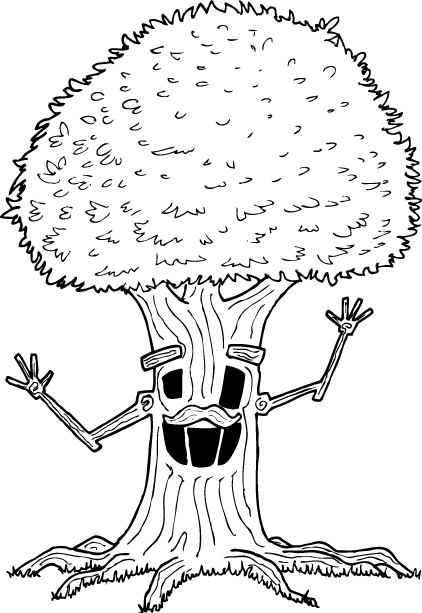

The function traverses the board and re-creates the `territory` structs for the `src` and `dst` of the attack. The former now has one dice, and the latter has changed owners. It also transfers dice so that `dst` receives all but one of the dice from `src`. The function `territory-set-player` is just like `territory-set-dice` in that it changes the `player` field of the struct.

## 10.10 The End Game

Naturally, we saved the end of the game for last. As you might remember, the `draw-end-of-dice-world` function uses `won`, which takes in the board and constructs text describing the final state of the board:

```
(define (won board)
  (define-values (best-score w) (winners board))
  (if (cons? (rest w)) "It's a tie." "You won."))
```

Calculating the winners from the board works like this:

```
(define (winners board)
  (for/fold ([best 0][winners '()]) ([p PLAYER#])
    (define p-score (sum-territory board p))
    (cond [(> p-score best) (values p-score (list p))]
          [(< p-score best) (values best winners)]
          [(= p-score best) (values best (cons p winners))])))
```

Here, we use `for/fold` to traverse the list of players. For each player, we get the number of occupied territories. When `best` is below `p-score`, the next loop iteration uses `p-score` as the winning score, and its list of winners contains only `p`, the unique identifier for the current player. When `best` is above `p-score`, nothing changes. Finally, when the two scores are identical, the loop adds `p` to the list of current winners. Since there are no other possibilities, the loop body covers all cases.

The very last function we need is `sum-territory`. It consumes a board and a player’s index, and it calculates the number of territories that the player owns:

```
(define (sum-territory board player)
  (for/fold ([result 0]) ([t board])
    (if (= (territory-player t) player) (+ result 1) result)))
```

This function is a simple `for/fold` that runs through the board and adds 1 to its return value every time it finds a territory that is owned by `player`.

Using this knowledge, Chad can finally beat Dicetromonom and proceed to the next level of DrRacket’s dungeons!

## `Kill`—Chapter Checkpoint

In this chapter, you encountered a new technique for manipulating a game using a game tree as a point of control.

- Creating a game tree produces a data structure that contains all legal moves from any state.
- Running a game becomes a mere matter of making sure turns are played according to the data in the game tree.

## Chapter Challenges

- **Medium**. Change our version of Dice of Doom so that the dice are rolled for an attack. Have both the attacker and defender roll the number of dice on their respective territories. If the attacker wins, she takes the territory. If the defender wins, the attacker loses all but one dice on her territory. You may want to get the random numbers from a third-party site, such as `www.random.org`. Here’s some code for retrieving a bunch of random numbers:

  ```
  (define (get-random-numbers)
   (define n 1000)
   (define src
     (string-append
      "http://www.random.org/integers/?num="
      (number->string n)
      "&min=1&max=6&col=5&base=10&format=plain&rnd=new"))
   (define ip (get-pure-port (string->url src)))
   ;; -- go get them --
   (for/list ((i n)) (read ip)))
  ```

- **Medium**. After implementing the previous suggestion, create a display that tells you the probability of winning an attack on the selected enemy territory.

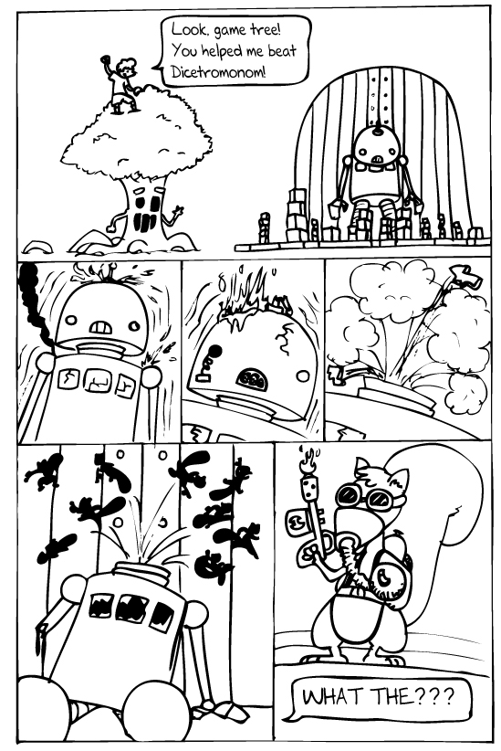

## Chapter 11. (Power to the Lazy)

#|

As every college student knows, being lazy is on occasion a remarkably effective way to get work done. What we mean, of course, is that some work just goes away if you wait long enough. In this chapter, we’ll show how these virtues of laziness carry over to the world of computation.

|#

## 11.1 Doomsday

Dice of Doom is fun, but the board is a little small. Try setting the board size so you get a 3×3 board and run the game. Did you notice that the generation of the game tree seems to just hang? It hangs because the time it takes to process the number of possible moves for a 3×3 board is massive compared to the time it takes for a 2×2 board. But think about it: do we really need to consider all possible moves at each step? The program should inspect only one move at a time, and many moves in the tree are never used. If there were some way to delay the generation of those subtrees that may not be needed immediately, we could make headway. There is a way, and it’s called lazy evaluation.

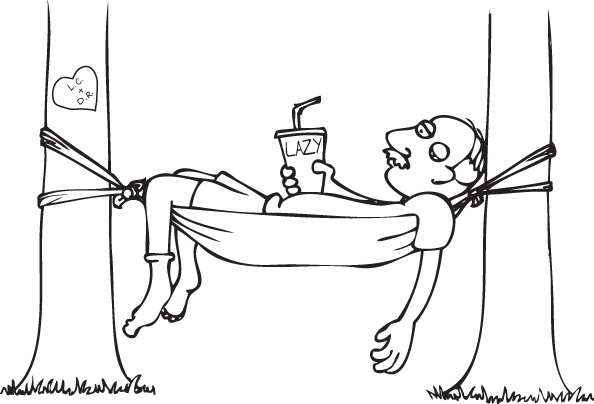

## 11.2 Lazy Evaluation

**Lazy evaluation** allows your program to delay computations until absolutely necessary. By doing so, it avoids a bunch of work that isn’t needed in the first place. So moves in our lazy game tree won’t be generated until the program asks for them. When it does ask for the moves, each subtree will undergo the same process, and it won’t be generated until it’s needed.

Another way to think about lazy evaluation is to imagine that the computation is being placed in a little box. We don’t know anything about the content of the box until we open it. Racketeers call this “box” a **suspended computation** or a **thunk**.

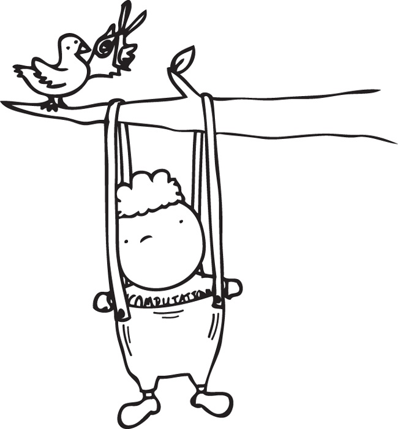

The simplest way to make a suspended computation is by wrapping a no-arguments `lambda` around an expression:

```
> (define lazy+ (lambda () (apply + (build-list 5000000 values))))
> lazy+
#<procedure:lazy+>
```

To obtain the value of the suspended computation, you just call the function:

```
> (lazy+)
12499997500000
```

Given the time it takes to compute the sum of a list of 5 million numbers, it’s easy to see why we would want to suspend the computation until we need its result, especially if we might never need it. But what if we end up needing that value again and again and again? Hold that thought. Let’s first look at some advantages of delaying computations.

The key advantage is that a program does not have to use all elements in a list of suspended computations. To illustrate this point, let’s define a function that creates suspended computations such as `lazy+`:

```
(define (make-lazy+ i)
  (lambda ()
    (apply + (build-list (* 500 i) values))))
```

This function consumes a natural number `i`, builds a list from `0` to `(* 500 i)`, and then returns the sum of the list. But really it doesn’t. Instead, `make-lazy+` wraps a `(lambda () ...)` around this expression, meaning it doesn’t immediately produce a sum. Rather, it produces a suspended computation that must be run to return the sum. If you apply this function to `10000`, you get `lazy+` back, but just getting `lazy+` back is boring. It would be better to build a list that consists of 5000 such suspended computations:

```
(define long-big-list (build-list 5000 make-lazy+))
```

At this point, you should be scared because computing all these sums might take an eternity—or a bit longer.

But we don’t have to compute all the elements in the list. We can easily write a function that computes only every 1000th element in the list:

```
(define (compute-every-1000th l)
  (for/list ([thunk l] [i (in-naturals)]
             #:when (zero? (remainder i 1000)))
    (thunk)))
```

Clearly, this `for` loop is run to create a list—the `/list` part says so. The second clause uses a novel element, `(in-naturals)`, though you can probably guess that it is a sequence of *all* natural numbers. So this loop runs over the given list and all natural numbers in parallel. Recall that this kind of loop stops when either of the two sequences is exhausted. Finally, the `#:when` clause makes sure that the body of the loop is run only when we have a natural number that is divisible by `1000`. The body itself is almost trivial; `thunk` refers to one element of `l`, and this element is a suspended computation. With `(thunk)` we retrieve its value.

Now consider this little program and guess what it will return when you run it in DrRacket:

```
> (compute-every-1000th long-big-list)
```

Do you get it? Don’t read on until you figure out the *shape* of the result. Once you hit the “Enter” key behind this expression in the interactions panel, DrRacket computes and returns a list of five numbers:

```
'(0 124999750000 499999500000 1124999250000 1999999000000)
```

Everyone can figure out the `0`; the remaining numbers require serious calculating. The key point, however, is that we never computed the vast majority of sums embedded in `long-big-list`.

[figure not shown]

## 11.3 Memoized Computations

It is time to return to the delayed question concerning the reevaluation of suspended computations. What happens if we need the value of a suspended computation time and again? Naively, it looks like we have to recompute the value as often as it is needed. Since recomputing the value is clearly time-consuming, Racketeers use memoization. But they do so only when a suspended computation doesn’t use effects, such as `set!` and friends.

**Memoization** is the technique of saving the result of a suspended computation in a hidden variable. If the result is needed again, it is enough to look at this hidden variable instead of rerunning the computation. Here is a first attempt:

```
(define (memoize suspended-c)
  (define hidden #f)
  (define run? #f)
  (lambda ()
    (cond [run? hidden]
          [else (set! hidden (suspended-c))
                (set! run? #t)
                hidden])))
```

This function returns a function that serves as a replacement for the suspended computation. When this replacement function is called, it checks whether it has been run before. If it hasn’t been run, the `suspended-c` function is called, and the result is saved in `hidden`. The replacement function sets `run` to true and then remembers it has been run. The next time it’s called, it can return the value of `hidden` without needing to run `suspended-c` again.

Now why does this work? Well, a `lambda` in Racket creates a **closure**, which captures all the bindings in the `lambda`’s context. This way, whenever a closure flows to a different scope, it can still reference all of its original bindings. Hence, the variables `hidden` and `run?` are enclosed with the returned computation. Any change to these variables affects how all copies of this computation run.

Memoization eliminates the need to call any time-consuming thunk more than once:

```
> (define lazy+ (lambda () (apply + (build-list 5000000 values))))
> (define mlazy+ (memoize lazy+))
> (mlazy+)
12499997500000
> (mlazy+)
12499997500000
```

Did you notice how little time the second evaluation of `(mlazy+)` took? That’s what memoization is about.

Here is a second definition of `memoize` for those who truly understand `set!` and functions as values:

```
(define (memoize.v2 suspended-c)
  (define (hidden)
    (define the-value (suspended-c))
    (set! hidden (lambda () the-value))
    the-value)
  (lambda () (hidden)))
```

Like `memoize`, this function both consumes and returns a suspended computation. The returned computation calls the locally defined function `hidden`. When `hidden` is called for the first time, it evaluates `suspended-c` and then changes the definition of `hidden` to a new different thunk. Thus, when `hidden` is called a second or third or whatever time, it merely returns the value of `suspended-c` without rerunning it.

The essential point of this trick is the call to `hidden` inside the suspended computation that `memoize.v2` returns. A change to this variable affects all copies of the suspended computation. This would not hold if `memoize.v2` just returned `hidden`. Think about it.

## 11.4 Racket Can Be Lazy

Fortunately, Racket has two built-in mechanisms to make your program lazy without you needing to rewrite a lot of code. One of them is an entire language called Lazy Racket. To use it, change the `#lang racket` at the head of your program to `#lang lazy`. The idea behind `lazy` is that absolutely every computation is a lazy computation. Nothing is ever computed until it’s needed, and everything is memoized. While we will not use Lazy Racket in this book, you can look it up in the documentation if you are interested.

The other mechanism is a library that gives us the ability to choose which part of the program is lazy. Unlike the `2htdp/image` and `2htdp/universe` libraries, the `#lang racket` line already imports this functionality because it is so important.

The most important forms in `racket/promise` are `delay` and `force`. The first one, `delay`, suspends a computation and returns a `promise`. A **promise** represents a suspended computation that can be evaluated at a later date with `force`. Let’s use the previous example of lazy evaluation:

```
> (define lazy+ (delay (apply + (build-list 5000000 values))))
> lazy+
#<promise:lazy+>
> (force lazy+)
12499997500000
```

As you can see, calling `force` on `lazy+` is like applying a `lambda`. Now notice something else. If you force `lazy+` again, the output is printed immediately:

```
> (force lazy+)
12499997500000
```

A promise created with `delay` is memoized. With `racket/promise`, everything is simplified and streamlined, so lazy evaluation and memoization become easy. Now we’re ready to create a version of Dice of Doom that can handle large boards via lazy game trees. And then we will use the leftover machine cycles to add an artificial intelligence.

## `Delay`—Chapter Checkpoint

In this chapter, we introduced a powerful new programming idea that can save your programs from doing needless work:

- Laziness procrastinates work until necessary.
- Memoization remembers the value of computations to avoid recomputing them.
- The `force` and `delay` forms express memoized laziness in Racket programs.

### Author’s Note:

#|

The following comics contain the flame thrower–wielding squirrels that were introduced as Dicetromonom’s head exploded in Chapter 10. We love these magnificent beasts and couldn’t imagine a book without them. To give them a bit more context and so that we could keep them in the comics, we want to mention one more thing about suspended computations. Remember how we described lazy evaluation as a “boxed” computation? Well, imagine instead that you put those computations into an old-school icebox. This “frozen” evaluation is just another word for suspended computation. Now, what could fireball-throwing squirrels have to do with frozen computations?

|#

[figure not shown]

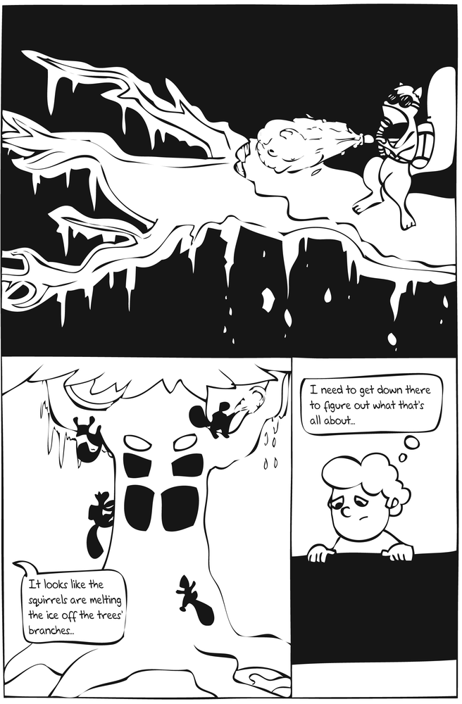

## Chapter 12. (Artificial Intelligence)

#|

Playing Dice of Doom against other people can be fun, but what if you could play against the program itself? What if the program were intelligent enough to win? We can make that happen with artificial intelligence (AI), that is, techniques that make programs appear as smart as people in narrow domains. In this chapter, we will make our implementation of Dice of Doom lazy and create an AI player.

|#

## 12.1 An Intelligent Life-form

Chad has finally beaten DrRacket’s Dicetromonom guard. In shock, Dicetromonom explodes, which gives Chad a chance to figure out what made Dicetromonom tick. He dissects Dicetromonom’s head and finds a small hard drive.

Chad plugs the drive into his computer and begins to examine the robot’s game software. He discovers a number of neat coding tricks. First, he notices that Dicetromonom can play on large game boards because it generates the game tree lazily. Second, he discovers Dicetromonom’s way of planning a game strategy, and it is amazingly simple.

## 12.2 Lazy Games

Recall that all our discussions of Dice of Doom in Chapter 10 involved 2×2 boards. If you tried to run the program on a larger board than that, it just wouldn’t work, unless you had access to a really great supercomputer. With the lazy evaluation trick from Chapter 11, we can easily improve the performance of our program. Laziness enables our program to play on large boards, and best of all, it saves some time.

Here’s how we use `force` and `delay` in our Dice of Doom game. First, we add `delay` to the `game-tree` function:

```
(define (game-tree board p dice)
  ;; create tree of attacks from this position; add passing move
  (define (attacks board)
    (for*/list ([src board]
                [dst (neighbors (territory-index src))]
                #:when (attackable? board p src dst))
      (define from (territory-index src))
      (define dice (territory-dice src))
      (define newb (attack board p from dst dice))
      (define gt-attack
        (game newb p (delay (cons (passes newb) (attacks newb)))))
      (move (list from dst) gt-attack)))
  ;; create a passing move and the rest of the game tree
  (define (passes board)
    (define-values (new-dice newb) (distribute board p dice))
    (move '() (game-tree newb (switch p) new-dice)))
  ;; -- START: --
  (game board p (delay (attacks board))))
```

Here, we have wrapped the generation of moves in `(delay ...)` as indicated in two places with bold. These `delay`s postpone the generation of all possible moves in `game` structs. In particular, the `for` loop in `attacks` and all direct and indirect recursive calls become suspended computations.

You may think that all we have to do is find all uses of the `game-moves` function and wrap them with `(force ...)` so that we get lists and not just suspended computations. While find-and-insert is indeed one way to apply all the requisite calls to `force`, in Racket there’s another way, and you will find the second one much more appropriate for this chapter. The second way is made for *lazy* programmers, that is, programmers who think hard and avoid manual typing on the keyboard until necessary.

The lazy way is to *redefine* the function `game-moves` once and for all. Doing so has a huge advantage: we don’t need to change the rest of the code at all. Better still, when we add code to the game, we don’t need to remember that `game-moves` retrieves a promise and that we need to use `force` to get the list from this promise. The forcing just happens automatically.

The following is the lazy way to define the `game` struct so that `game-moves` forces its field every time it is used:

```
(define-values (game game? game-board game-player game-moves)
  (let ()
    (struct game (board player delayed-moves))
    (values game
            game?
            game-board
            game-player
            (lambda (g) (force (game-delayed-moves g))))))
```

It is a mouthful of code, and it is complicated, but once you understand this trick, you will find that it is extremely useful in many situations. We will use it again in Chapter 14.

The first line in this code snippet sets up a multiple-values definition. Specifically, it defines five functions: `game`, `game?`, `game-board`, `game-player`, and `game-moves`. If you squint just a bit, you see that these are precisely the functions introduced by this structure definition:

```
(struct game (board player moves))
```

The second line sets up a local scope of definitions, and the third line defines the expected `game` struct in that scope. The function definitions that it introduces are visible only inside of `(let ...)`. The trick is that the next expression is a `values` expression that bundles up `game`, `game?`, `game-board`, and `game-player`, plus one more function so that they match up with the variable names introduced by `define-values`.

In short, we use the power of Racket to change a large program in two small ways to get a large change in behavior. You can mimic some aspects of laziness in other languages, but this isn’t normally one of those ideas you see early on. With Racket, however, it can become a part of your first-year repertoire.

Now you may wonder why the call to `force` doesn’t create the whole game tree, canceling all the benefits we get from suspending the game tree generation in the first place. To understand why it works, take a second look at `game-tree`. Once we `force` the list of moves, the next step is always to call the locally defined `attacks` function on `board`. This call will indeed create one complete level of the game—a complete list of moves—with a `delay`. Furthermore, because of the recursive nature of `game-tree`, the generation of the tree is suspended in each node attached to a move. Only the next call to `force` will unfold one more level passing of the game tree, but only for the moves the game needs to execute. And voilà, you have a lazy version of Dice of Doom.

Lazy Dice of Doom has two advantages over our first draft of the game. First, Lazy Dice of Doom no longer needs restrictions on the rules that make Dice of Doom a finite, terminating game. It is okay to play infinite games now, because the game tree is unfolded only as much as needed, and we never need more than a finite portion. Second, Lazy Dice of Doom is good not only for playing infinite games, but also for playing on large game boards.

Try it out. Play on a 3×3 or 5×5 board. But just playing the game by yourself is boring, even with a bigger board. Let’s make the game interesting by adding AI.

## 12.3 Adding Artificial Intelligence

The strategy of search and evaluate is one idea behind John McCarthy’s notion of AI. For games, this idea works amazingly well and truly invokes the perception of intelligence. Our game’s AI will search the game tree, evaluate all moves, and determine the best one. To complete the evaluations, we will use something called the **minimax** algorithm.

The principle behind the minimax algorithm is “what is good for me is bad for my opponent,” and vice versa. Hence, the algorithm minimizes the maximum damage an opponent can inflict during a turn. Roughly speaking, the algorithm proceeds in two steps. First, it assigns a value to each move in the tree, up to a certain level. Second, it determines the minimum of the maximal damage at each level of the tree, from the perspective of the current player. At the root of the game tree, the AI picks the move that results in the best possible outcome as far out as the algorithm can see.

To write the AI, we need a depth limit:

```
(define AI-DEPTH 4)
```

We do not want the AI to make an evaluation beyond a certain depth in the game tree. Otherwise, the AI forces every single level in the game tree, and we lose all the advantages of going lazy. For this game, we define the depth to be 4, so the AI will evaluate only four moves deep into the tree. The depth limit reduces the AI’s intelligence but without it the program would run too slowly.

Next, we should write a function that limits the evaluation of the tree. This `prune-tree` function would take a game tree and the desired depth of evaluation. It would then create a `game` structure and recursively trim each branch via a `for` loop.

The process could stop when the desired depth reaches `0`. But we don’t write a separate tree-pruning function. Instead, we prune as we go. That is, the rating function evaluates the moves as it goes and stops evaluating when it reaches the specified depth.

As it turns out, we actually need a pair of rating functions: one for rating moves in the tree and one for rating positions. Here is the first one:

```
(define (rate-moves tree depth)
  (for/list ([move (game-moves tree)])
    (list move (rate-position (move-gt move) (- depth 1)))))
```

The `rate-moves` function consumes a tree and a depth. With a `for/list` loop, it produces a list that pairs each move with the rating of the position that results from this move. The latter is obtained via `rate-position`, the function that assigns a value to each tree:

```
(define (rate-position tree depth)
  (cond [(or (= depth 0) (no-more-moves? tree))
         (define-values (best w) (winners (game-board tree)))
         (if (member AI w) (/ 1 (length w)) 0)]
        [else
         (define ratings (rate-moves tree depth))
         (apply (if (= (game-player tree) AI) max min)
                (map second ratings))]))
```

The function generates a numeric point rating for a given branch of the game tree. If the function has reached the desired depth or the state has no further moves, we’ll need to check who the winner is for the current position. If the current player isn’t among the winners of this position, we can give the position the minimum rating of `0`. Otherwise, we’ll divide `1` by the number of winners to determine our rating. By doing this, we also give a meaningful rating for ties. If the player is the sole winner, the rating, according to this formula, will be the maximum value of `1`. For a two-player tie, the rational result would be `1/2`.

If, however, more moves are available, we’ll need to look at all the subsequent moves to decide how to rate the current position. We accomplish this by calling our `rate-moves` function. As per the minimax principle, we will then pick either the `max` or `min` rating of all the follow-up moves, depending on whether the move being rated is for the AI player or its opponent.

Now we can bring all of these functions together into a single function that acts as an artificially intelligent player. In this role, `the-ai-plays` takes a game tree and determines the best possible moves at the given tree node:

```
(define (the-ai-plays tree)
  (define ratings  (rate-moves tree AI-DEPTH))
  (define the-move (first (argmax second ratings)))
  (define new-tree (move-gt the-move))
  (if (= (game-player new-tree) AI)
      (the-ai-plays new-tree)
      new-tree))
```

The function starts by rating all possible moves from the root of the given tree to some fixed depth. The best move is determined by Racket’s higher-order `argmax` function, which finds the element of `ratings` that maximizes the output of `second`. So in this case, it returns the move that has the maximum rating, and then `the-ai-plays` creates a new game tree from it. If the current player after this move is still the AI player, then `the-ai-plays` continues to pick moves. Otherwise, it returns the new game tree.

All that’s left to do is link the AI into Dice of Doom. To this end, we modify the `pass` function to allow the AI to take over the role of the players:

```
(define (pass w)
  (define m (find-move (game-moves (dice-world-gt w)) '()))
  (cond [(false? m) w]
        [(or (no-more-moves? m) (not (= (game-player m) AI)))
         (dice-world #f (game-board m) m)]
        [else
         (define ai (the-ai-plays m))
         (dice-world #f (game-board ai) ai)]))
```

This new version calls the AI when it is the AI’s turn; otherwise, the function just passes the turn normally.

We now have a fully functional game that employs an AI. Try it out!

## `Stop-when`—Chapter Checkpoint

In this chapter, we used lazy evaluation to improve Dice of Doom, and then we created an AI player so that you can play against the program:

- Lazy evaluation allows us to make the game more efficient so that it can handle larger game boards by ignoring branches of the game tree until they are absolutely needed.
- We used a simple minimax algorithm to create an AI player.
- Finally, you learned how to define structures that implement more than just the built-in constructors, accessors, and predicates.

## Chapter Challenges

- **Easy**. Make the AI step through its moves. Right now, it executes all of its moves at lightning speed, leaving players slightly dazed by the crushing blows that it inflicts. It will be easier for the player to understand if the AI executes its moves step-by-step instead of all at once.
- **Medium**. Create a hint feature. When you press a certain key, a good enemy territory will be highlighted as a suggested attack. Hint: This will require you to use some of the pieces of the AI for the human player.
- **Difficult**. Search the Web for other AI algorithms that an automated Dice of Doom player could employ against you. Then turn the new player loose on your friends.

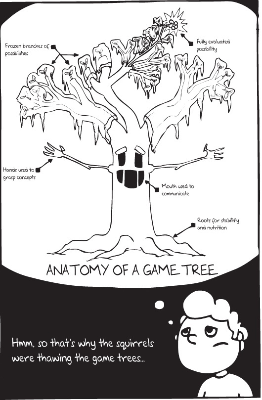

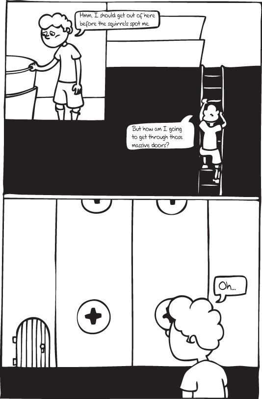

## Chapter 13. (The World Is Not Enough)

#|

In the beginning, you drew images, you built GUIs, you created games, and you fabricated entire worlds. But that’s not enough. In this chapter, we will show you how to write programs that work across multiple computers. We will show you how to construct complete universes from your worlds in preparation for our greatest creation: the best and most entertaining game ever.

|#

## 13.1 What Is a Distributed Game?

The games we’ve written so far have one major shortcoming: they run on one computer, which makes multiplayer games awkward. So far, our multiplayer games require players to crowd around one keyboard as they all take turns tapping on it. But many multiplayer games run on a network and allow players from all over the world to interact with each other. To create this kind of game, we need to introduce you to **distributed programming**.

In order to create a distributed game, we set up a **server** that acts as a central communication point for the game. The players’ computers all act as clients that connect to this server and communicate with each other via messages routed through this server. Usually, the server will handle the logic of the game and enforce the rules, informing the clients about changes to the state of the game as needed. In contrast, the **clients** deal with players’ inputs, draw the current game state, and notify the server of the players’ actions.

Creating a server resembles creating a world. A server is basically a world that doesn’t draw its state and that has the ability to accept multiple connections from client worlds anywhere on the Internet, even the very computer it runs on. The latter is important when you develop your games. It’s only later that you really want people from anywhere in the world to connect to your game server.

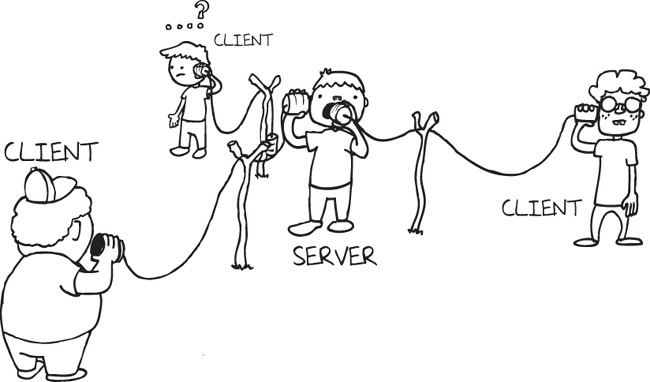

Technically, the key differences between a server and a world are that the former uses a `universe` expression instead of `big-bang` and that a `universe` expression comes with different kinds of event-handling clauses than those of a `big-bang` expression. In addition, we need to tell you about new kinds of events and about a new way to write event handlers for worlds. So in this chapter we will go over the `universe` system and the new ways of writing `big-bang` expressions.

Let’s look at the big picture first. When a server is available, worlds can register with a server. The act of registering with a server is an event for the universe, and it deals with these registration events in the same way that worlds deal with key-events. All the clients exist in their own realms, live on their own cycles, react to their own inputs, and so on. If an event handler in one world needs to communicate with the universe, it returns a new world state and a message to be sent to the server. The arrival of the message is also an event for the server, and some event handler takes care of it. One possible reaction is to send mail to other worlds. Naturally, the arrival of a message at a world is just another kind of event, and if a world is equipped with an event handler for messages, this event handler is applied to the current state of the world and the incoming message—just like a key-event handler is applied to the current state of the world and a key-event. But enough of the abstract picture. It’s time for a concrete example.

## 13.2 The Data

Let’s go over all the new items in detail, starting with messages.

### Messages

In reality, messages aren’t a new kind of data; they are any of the data introduced in Chapter 3, and we call them messages because they are sent across the network. Put differently, a message is a number, symbol, string, Boolean, or nested list containing only messages. Following good old John McCarthy, we call this form of data an **S-expression**.

If the client or the server tries to send other forms of data, Racket will signal an error. The error message says, “`expected <S-expression> as argument`,” and it means the data your program sent is not a message.

### Previously Fabricated Structures

But this picture isn’t quite complete. There is one more type of message that we need to mention: a previously fabricated structure, or **prefab**. Prefabs are a kind of structure designed for operations like network communication. They, too, can be sent across the network like any other kind of message, as long as they contain only messages, like lists or other prefabs. This becomes useful when a client and server need a similar structure type, like the representation of a player.

Prefabs also print a little differently than regular structures:

```
> (struct foo (bar) #:transparent)
> (foo 5)
(foo 5)
> (struct foo (bar) #:prefab)
> (foo 5)
'#s(foo 5)
```

This printing difference is related to why prefabs work for network communications, but that’s not really important here. If you want to know more, you can look it up. What is important here is that when you see `'#s`, you’re dealing with a prefab.

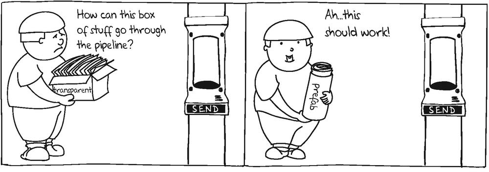

### Packages

The first new kind of data is a **package**, built with the `make-package` function. A package combines two pieces of data: a world state and a message. In order to send a message to its server, a client’s event handler returns a package to `big-bang` instead of just a world. The world state in the package becomes the new world, and the message in the package is sent to the server. And who does this sending? Why, `big-bang`, of course.

### Bundles

A **bundle** is the `universe` equivalent of a package. All handlers in a `universe` expression construct it with the `make-bundle` function. A bundle wraps up all the data that the server needs to continue its operation: the new universe state, a list of messages to send to clients, and a list of clients to drop. Unlike packages, however, bundles are mandatory—every event handler in a `universe` expression must return a bundle.

### Mail

The second argument of `make-bundle` is not just a simple list of messages; it’s actually a list of **mail**, each piece created with `make-mail`. The mail we refer to here is like mail in real life. It contains two pieces of data: an address and a message in S-expression shape. When the universe encounters a `mail`, it sends the message to the client with that address.

### iworld Structures

So what data do we use as addresses? Take another look at the comic in 13.1 What Is a Distributed Game?. Not only is it funny, but it also illustrates how network connections work. To represent the addresses and the connections, `universe` uses `iworld`s. Most importantly, an `iworld` structure includes the wired connection between a client and the server. When a new client connects to your `universe` server, the `universe` creates an `iworld` for the client and hands it to the event handler for new connections. When a new message arrives, the handler for new messages is applied to the `iworld` that represents the sender. When messages need to be sent to a client, the server finds all the necessary information in the `iworld` struct inside mail. Hence, `iworld`s can serve as addresses.

If you read the documentation for `iworld`, you will notice that `iworld`s come without an `iworld` constructor. This gap is not an oversight in the design of `2htdp/universe`; it’s a deliberate choice. Only `universe` can construct `iworld`s when clients sign up. Its event handlers may use, but not create, `iworld`s. Indeed, to make sure your programs don’t make mistakes, the `iworld` structures are `#:opaque`. There is no way to look inside such a structure. For testing purposes, there is an `iworld=?` function and a few predefined `iworld`s: `iworld1`, `iworld2`, and `iworld3`.

## 13.3 The Network Postal Service

Roughly speaking, `universe` works like `big-bang`. It looks at the given clauses and uses them to decide how to react to events, such as the receipt of a new message, the request for a new connection to a world, or a clock tick.

The `universe` form comes with two mandatory clauses: `on-new` and `on-msg`. The `on-new` clause handles new connections. The function used for this clause takes in the current state of the `universe` and the `iworld` that represents the new connection. Like all `universe` functions, it must return a bundle. The `on-msg` clause deals with messages from already connected clients. Its corresponding handler function consumes the current state of the `universe`, the `iworld` representation of the client who sent the message, and the actual message. When it is finished, it returns a bundle.

In addition to `on-new` and `on-msg`, programmers may use several optional clauses to describe the workings of a `universe` server, such as `on-tick` and `connect` clauses. For more information, consult the Racket documentation. We will use only the mandatory clauses in this chapter.

The `big-bang` form gets two new clauses to enable network communications. The first of these is the `register` clause. Unlike the other clauses, it doesn’t come with a handler function; rather, it gives the IP address of the server that `big-bang` should connect to, such as `"192.168.0.10"` or `"realmofracket.com"`. If the server happens to be running on the same machine, put the constant `LOCALHOST` here. This constant is provided by `2htdp/universe` and points the client to your computer.

The second new `big-bang` clause is `on-receive`. It does exactly as its name implies: it handles the receipt of a message from the server. Its handler function consumes the current state of the world and the message from the server. After some computing, it returns either a world or a package.

## 13.4 Organizing Your Universe

Writing distributed programs can get messy. Servers and clients often need to share code, but putting everything into one file would make our code confusing. Ideally, we should organize our code into three separate **modules**: one for the client, one for the server, and one for shared material. The purpose of a shared module is to allow the client and server to reuse its definitions. It is also a good place to document how the server and its clients communicate.

A Racket module is a file that starts with `#lang racket`. Getting definitions from another file is easy. In fact, we have done this in most of our programs. When we say `(require 2htdp/image)`, we’re telling Racket to look in the main collection of libraries, called **collects**, go to the **2htdp** folder, and get the code from the **image.rkt** file. If we wanted to grab definitions from a file elsewhere, we would put in a string with the name of the file relative to the current module. For instance, `(require "source.rkt")` would retrieve the provided names from the **source.rkt** file in the directory where the current module is located.

We need to be careful when sharing code between modules. On occasion, we may wish to hide some functions in one module to prevent another module from using them incorrectly. Therefore, you must explicitly say what you’re making visible outside your module with a `provide`. By specifying what can be accessed, the purpose of the module also becomes clearer, which makes the code easier to read.

Here is an example:

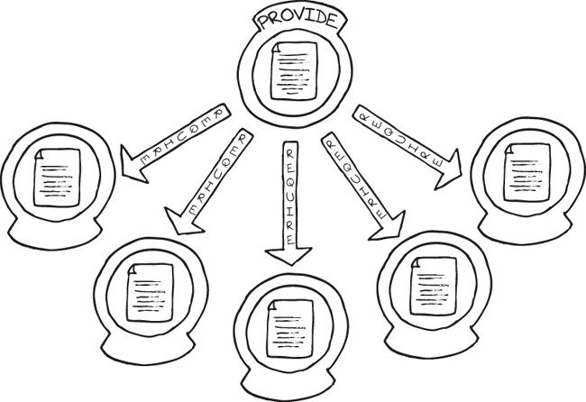

### foobar.rkt

```
#lang racket
(provide foo addone)
(define foo 5)
(define (addone) (set! foo (addx 1)))
(define (addx x) (+ foo x))
```

This module allows access to `foo` and `addone`. A simple `(require "foobar.rkt")` is enough. However, it is impossible to access `addx`. It is also forbidden to use `set!` directly on `foo` in a `require`-ing module. Racket imposes this restriction to prevent client modules from interfering with your module’s internal state. If you want a client module to modify a variable in your own module, you must provide a function such as `addone`.

For convenience, Racket gives us a way to provide every function declared by a structure so we don’t have to type it all out ourselves. It’s called `struct-out`:

### barbaz.rkt

```
#lang racket
(provide (struct-out bar) (struct-out baz))
(struct bar (a b))
(struct baz (a [b #:mutable]))
```

The `provide` statement here is the same as saying this:

```
(provide bar bar? bar-a bar-b baz baz? baz-a baz-b set-baz-b!)
```

As you can see, the first one is shorter and usually clearer. So use it!

## 13.5 Distributed Guess

Remember Guess My Number? We have already written two versions of this game, and now it’s time to develop a third one. Using our knowledge of modules and `universe`, we’ll develop a distributed variant of the game—one that runs on a network. As before, the player picks a number between 0 and 100. But now he creates a client, and the client connects to a central Guess My Number server—think something like `www.guess-my-number.com`—and it is this server that attempts to guess the number that the player has in mind. The server deals with one client only; if another client tries toconnect when a game is already in progress, the server just drops the connection.

As in our GUI version of Guess My Number, the player will respond to each guess with an “↑” or “↓” signal, where the former means the number is larger than the guess and the latter means the opposite. The player may press “=” at any time to signal that his number was found or “q” to quit the game.

From these rules, you can see that the client needs to send only two messages to the server: `"up"` and `"down"`. In turn, the server needs to react to just these two kinds of player responses, and it does so with a new guess. Since a guess is a number, we know that the server always sends a number to the client. When the server guesses the client’s number correctly, it expects the player to admit defeat, which will close the connection on the client’s side. Once a `universe` discovers that the client has disconnected, it reboots to its initial state. In our case, this means the server is ready for the next Guess My Number client.

After some thought, you may realize that the server can reuse many functions from the GUI version of the game. So all we really need to add is the communication software. But we’re getting ahead of ourselves. Remember that after determining what kind of messages the server and the client(s) exchange, we need to figure out which portions of the distributed game go into which of its three modules. In this book, we use the file names **shared.rkt**, **client.rkt**, and **server.rkt**.

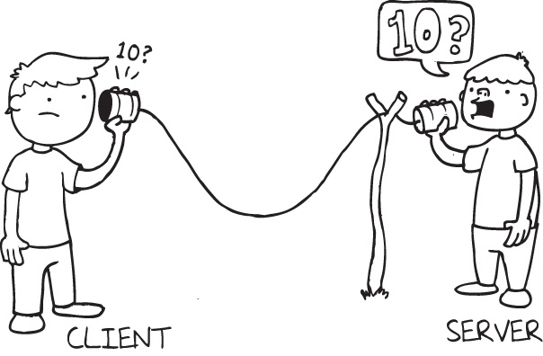

When you develop a distributed game, you always start with a **shared.rkt** file. Because of the simplicity of the Guess My Number game, the shared file consists of two constant definitions: the upper and lower bounds of the guesses. The client needs these limits to tell the player what range to pick a number from, and the server also needs these in order to guess an appropriate number.

Here is the complete file:

### shared.rkt

```
#lang racket
(provide UPPER LOWER)

#|
In the Distributed Guess My Number game, a player uses a client to
connect to the server. The server attempts to guess what number the
player is thinking of. Each time the server guesses, the player must
use the arrow keys to tell the server if it is too small or too large.

A StoCMessage, a server to client message, is any natural number
between LOWER and UPPER (inclusive). The numbers represent the guess.

A CtoSMessage, a client to server message, is one of the following
two strings:
-- "up"
-- "down"
with the obvious meaning.
|#

(define UPPER 100)
(define LOWER 0)
```

We also add a block comment that describes the purpose of the project and the messages that go from the server to the client and vice versa. So **shared.rkt** really contains all the information that represents common knowledge for both clients and servers—even if some of it has to be in comment form.

### The State of the Client and the State of the Server

The second step is to figure out the state of the client and the state of the server. For Guess My Number, the client needs to keep track of the most recent guess it received from the server, as well as whether the server has even sent a guess yet. We choose strings to represent these states, which implies that the `on-receive` handler must convert guesses to strings on arrival. Let’s start with the client’s initial world state:

### client.rkt

```
#lang racket
;; clientstate is a string
(define clientstate0 "none available")
```

The server’s state is a little more complicated than the client’s state. As mentioned, the server has the same logic as the second version of Guess My Number. It needs the interval for guessing appropriately, but it also needs to know whether it’s connected to the client. As you can imagine, this calls for a state representation with two distinct cases:

### server.rkt

```
#lang racket
;; GmNState is one of:
;; —(interval nat nat)
;; —#f
(struct interval (small big))
(define u0 (interval LOWER UPPER))
```

The `interval` structure is pulled right out of Chapter 5, and naturally, the initial interval is bounded by `LOWER` and `UPPER`. When the universe state is `#f`, no client is connected to the server.

### The Server

As always, we start the server module with the main function:

### server.rkt

```
(define (launch-guess-server)
  (universe #f
            (on-new connect)
            (on-msg handle-msg)))
```

The initial universe has no client connected to it, so its state is `#f`. The only clauses that the server needs are `on-new` and `on-msg`.

When a client attempts to connect, the server can either accept the connection or ignore it. The `connect` function in our `on-new` clause decides whether to accept a new connection depending on whether the server is already connected to a client:

### server.rkt

```
(define (connect u client)
  (if (false? u)
      (make-bundle u0 (list (make-mail client (guess u0))) '())
      (make-bundle u empty (list client))))
```

If the state is false, then no client has connected. So `connect` accepts the client, sets the initial state to `u0`, and sends a guess for `u0`. Otherwise, the server is busy and the new client is dropped. The drop is accomplished by returning a bundle of the current state of the `universe`, an empty list of mail, and a list containing the `iworld` of the client that is trying to connect.

The `handle-msg` function is also simple:

### server.rkt

```
(define (handle-msg u client msg)
  (define w (next-interval u msg))
  (make-bundle w (list (make-mail client (guess w))) '()))
```

First, it determines the next interval based on the client’s message. Second, it returns this interval as the state of the universe in a bundle, with a new guess for its client in the mail.

And that brings us to `next-interval`:

```
(define (next-interval u msg)
  (cond [(not (string? msg)) u]
        [(string=? "up" msg) (bigger u)]
        [(string=? "down" msg) (smaller u)]
        [else u]))
```

If the client’s message is not a string, then the server will regard the message as junk and won’t change anything. You may think that we don’t need to check whether the message is a string, but you never know who connects what kind of code to the server, so we are better off protecting it. A computer scientist says that such a `cond` clause makes the server **fault tolerant**.

The next two clauses check the client’s response. If the client tells the server that its guess was too big or small, then the server does the same thing as the program from Chapter 5. It modifies its `interval` using either `smaller` or `bigger`.

The functions used on intervals—`smaller`, `bigger`, `guess`, and `single?`—are taken directly from the source of Chapter 5. Just plop them into **server.rkt**.

As you may have guessed, the last `cond` clause is another one that we introduced for fault tolerance. Even if the client sends a string, you never know what kind of string you’ll get. It’s best to ignore bad strings explicitly.

### The Client

The code for the distributed Guess My Number client is just as short as the code for the server. Once again, we start with a main function to launch `big-bang`:

### client.rkt

```
(define (launch-guess-client n)
  (big-bang clientstate0
            (to-draw draw-guess)
            (on-key handle-keys)
            (name n)
            (register LOCALHOST)
            (on-receive handle-msg)))
```

The function consumes a string and spawns a world whose initial state is an informative string. This `big-bang` looks just like the ones we’ve written throughout the book, with the exception of three clauses: `name`, `register`, and `on-receive`. So let’s first look at its function, `handle-msg`:

### client.rkt

```
(define (handle-msg c msg)
  (number->string msg))
```

This function translates its message to a string, which becomes the current state.

Handling key-events is similar to what we’ve seen before:

### client.rkt

```
(define (handle-keys w key)
  (cond [(key=? key "up")   (make-package w "up")]
        [(key=? key "down") (make-package w "down")]
        [(key=? key "q")    (stop-with w)]
        [(key=? key "=")    (stop-with w)]
        [else w]))
```

If the player presses a valid arrow key, the handler sends that message to the server using `make-package`, and the world state in that package becomes the new world. When either the “q” or “=” key is pressed, `stop-with` ends the game, as you know from preceding chapters. Finally, if the player doesn’t use any relevant keys, we just ignore the keystroke. It’s simple.

The `to-draw` clause is nearly identical to the drawing function from Chapter 5:

### client.rkt

```
(define (draw-guess c)
  (overlay (text c SIZE COLOR) MT-SC))
```

### Running the Game

That’s it. You have now seen all the code that is needed for a distributed game. Although building the game brought up several new concepts, the code itself is simple. If this simplicity surprises you, keep in mind that `2htdp/universe` hides some magic. Then again, this is what good languages do for you.

In principle, you could now copy the code onto two different computers, start the server, start the client, and play the game. This sounds cumbersome, and if you have a mistake in the code, you need to repeat this procedure again. And again. So it won’t surprise you to find out that `2htdp/universe` comes with a tool to explore distributed programs on one machine. The right way to do this is to create a fourth file—call it **run.rkt**. Here is the entire file:

### run.rkt

```
#lang racket
(require 2htdp/universe "server.rkt" "client.rkt")
(define (run)
  (launch-many-worlds (launch-guess-client "Adam")
                      (launch-guess-server)))
```

It requires the client module, the server module, and `2htdp/universe`. From the latter, it receives `launch-many-worlds`. The run function uses `launch-many-worlds` with two function calls:

```
(launch-guess-client "Adam")
(launch-guess-server)
```

As you may have guessed, the first is given a string and launches a client world; the second runs a server. Then the former connects to the latter, and the two work together.

Now go and play the game with a friend. You deserve it.

## `Error`—Chapter Checkpoint

In this chapter, you have seen the basics of distributed game programming:

- The universe form and its `on-new` and `on-msg` clauses
- The representation of client worlds via `iworld` structs
- The server’s event handlers and the bundles they return
- Prefab structs for network communication
- The `on-receive` clause for `big-bang`
- The packages that `big-bang` handlers may return
- Racket modules for organizing code

We know that this bombardment of ideas can be a bit overwhelming. Do experiment with the code for this chapter. And when you are ready, read on. Chapter 14 promises to introduce the best game yet.

## Chapter Challenges

- **Easy**. Design a version of the distributed Guess My Number game in which two human players face off. The first player who connects to the server should set the number to be guessed, and the second player to connect must guess that number.
- **Medium**. Try writing a simple chat client and server. When you finish, you can use it to talk to your friends in class, instead of paying attention to the professor. See *How to Design Programs, Second Edition* (`www.ccs.neu.edu/home/matthias/HtDP2e/`) for hints.

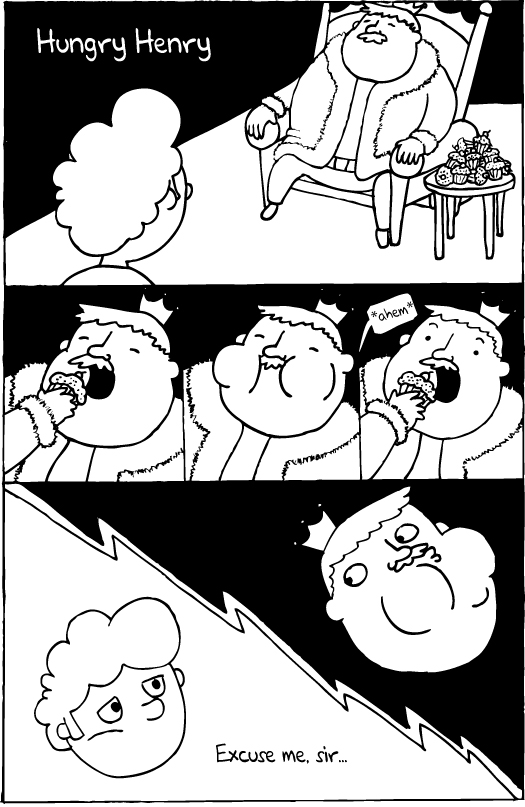

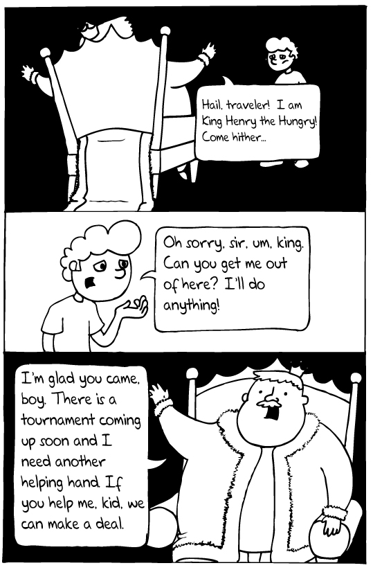

## Chapter 14. (Hungry Henry)

#|

Guess My Number is good and all, but it’s getting a little old. Let’s take everything we have shown you and create a distributed game from scratch. Today, we feed Hungry Henry.

|#

## 14.1 King Henry the Hungry

After fleeing from the squirrels, Chad resumes his search for a way out of the dungeons. While exploring, Chad comes across an enormous man sitting on a golden throne. “Hail, traveler!” the man calls, “I am King Henry the Hungry!” Then he proclaims, “Come hither, I have a proposition for you!” As Chad approaches, the king begins to tell his story. “Long ago, I was just like you, boy, a prisoner in the dungeons of DrRacket. Starving, I created a program to gather food, and what better food to eat than cupcakes? I forgot the `stop-when` clause and have been happily eating cupcakes ever since.”

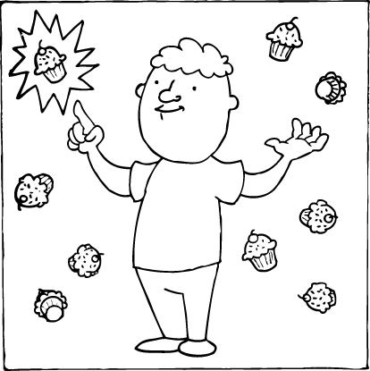

The king continues, “I’ve had so much practice that I could beat anyone at a cupcake-eating competition, and now is the time to prove it. But I need your help to change my program so that the whole world can participate. If you help me, I will help you find a way out.” Can you help Chad run Hungry Henry’s tournament?

## 14.2 Hungry Henry, the Game

The goal of this chapter is to turn King Henry’s eating competition into a distributed game. A server sets up a field of cupcakes and waits for players to sign up for a round of Hungry Henry. Once a player connects to the server, she is given her own avatar to control. The objective of the game is to navigate this avatar around the screen, getting to cupcakes before other players do. To navigate, the player sets waypoints on the screen by clicking the desired location. The avatar then travels to each of these waypoints in turn. But players must choose these waypoints carefully. Once one has been added, it may not be removed. Each time an avatar collides with a cupcake, the food is removed and the avatar increases in size. Of course, a growth in girth means the avatar slows down.

When all the food is gone, the game displays a table that lists the players and the number of cupcakes they ate. After a delay, the game restarts. If a player attempts to join while a game is in progress, she will be forced to watch. Once the game restarts, these spectators are assigned avatars, too.

## 14.3 Two United States

Before we show you how to implement the Hungry Henry game, we need to drill down on one more concept: the **state machine**. While all world games are state machine games, Hungry Henry makes explicit use of two distinct states in two different state machines.

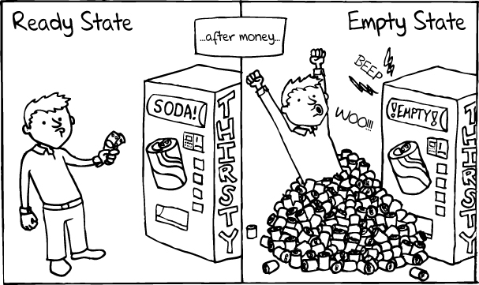

Consider the ubiquitous soda machine. Initially, it is full. You put in a dollar bill, and the machine responds by dispensing a can of soda. The machine is now in a different state; it is partially empty. Eventually, it will dispense its last can and enter its final state, the empty state. Think of Hungry Henry’s state machines like this, but with less liquid and more cupcakes.

In this chapter, the universe and all of its worlds are in one of two different kinds of states: **waiting** and **playing**. The universe starts in a waiting state. When it’s time for the game to start, the universe switches to a playing state. Our program will thus need to understand how to handle events depending on the current state of the universe. Distinguishing these two states will significantly simplify our data and message protocol.

## 14.4 Henry’s Universe

Our next step is to divvy up responsibilities between the server and the clients, and these responsibilities need to be carefully assigned. For example, if we let the client handle the movement of her avatar or the eating of cupcakes, who will enforce the rules of the game? You could easily imagine a player changing the client code to her own advantage. So our choices must prevent players from acting in this malicious manner.

The client will be responsible only for reporting a player’s mouse clicks to the server and rendering the current state of the game. Essentially, the client will implement the `on-mouse` and `on-draw` specs for `big-bang`. The server, in contrast, does a lot more work. It is in charge of handling movement, collisions, eating, and ending the game. And, of course, whenever something changes, the server sends the new state of the universe to all the clients.

### Message Data and Structures

So what kind of information is actually sent from client to server and vice versa? While the client needs to send only information about where the player clicked on the screen, the server needs to send back four kinds of messages: an ID to inform the player of her avatar’s name, a fraction of the waiting period that has passed, the current state of the avatars and cupcakes, and the final scores.

To keep the protocol simple, the multipart messages are lists tagged with a symbol that identifies the type of message. Here is the only type of message the clients can send:

```
(list GOTO Number Number)
```

It is just a three-part list: a constant to identify the message type and the *x*-coordinate and *y*-coordinate of a mouse click.

Two of the server’s messages are even simpler than that. When a client registers, the server responds with a new unique ID for the avatar. By defining an ID as a string, the server can make use of `iworld-name` to generate an easily recognizable ID.

The most complex message describes the state of the game:

```
(list SERIALIZE [Listof Player] [Listof Cupcake])
```

This message is a three-element list containing the constant `SERIALIZE`, a list of players, and a list of cupcakes.

Players are represented with prefab structures:

### shared.rkt

```
#lang racket
(provide ...
         (struct-out player)
         (struct-out body)
         ...)
(struct player (id body waypoints) #:prefab)
```

Players need their own ID, which clients use to differentiate themselves from other players. The next field, `body`—think an astronomical body—is used to describe the location and size of a player. The last field, `waypoints`, is a list of waypoints from oldest to newest, the order in which the avatar will travel. Ordering points in this way is efficient because the program must look at the head of the list many times as the avatar moves incrementally along its path.

Both avatar bodies and cupcakes can be described as physical bodies:

### shared.rkt

```
(struct body (size loc) #:prefab #:mutable)
```

The first field, `size`, is a positive integer that represents the radius of the `body`. The second field, `loc`, is a complex number that represents the actual location of the `body`. The structure is mutable to make it easy for the server to grow or move any object.

Finally, the score message contains just the expected table:

```
(list SCORE [Listof (list ID Number)])
```

At the end of the game, the server will send a list of two-element lists. The first element is a player’s ID, and the second is the player’s score.

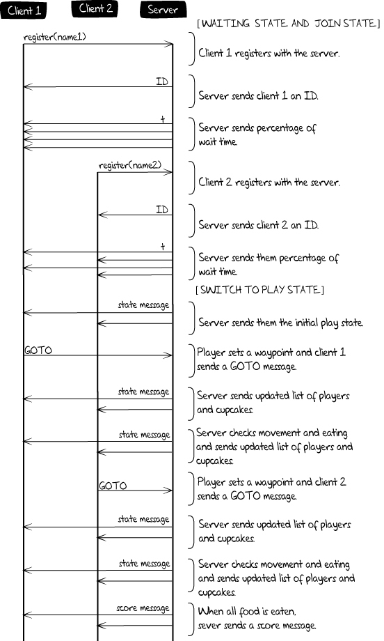

### Complex Numbers Are Good Positions

Complex numbers, such as `3+2i`, are convenient for representing coordinates, so we’ll use them for waypoints. To model movements, we can use normal math operators, such as `*` and `+`. To access the *x*-coordinate of a complex number, we use the built-in function `real-part`, which gives us the real portion of the complex number. To access the *y*-coordinate, we use `imag-part`, which extracts the imaginary portion. If there is a need to construct an imaginary number from two real numbers, we use the `make-rectangular` function, which takes two real numbers and returns a complex number, where the real part is the first number and the imaginary part is the second number.

### A Day in the Life of a Server

In the beginning, our server just ticks along, waiting for a client to join. When a client connects to the server, it is sent an ID. During this phase, the server continually keeps its clients up-to-date with the approximate time left until the game starts. Once time has run out and enough players have signed up, the server switches to a play state. From this point on, any new clients are considered spectators, and the server tells the players and spectators the location of all the food and avatars in the game. Once the players have eaten all of the food, the server tallies the scores and sends a `SCORE` message to the clients. Afterward, it resets to its `join` state, joining together all the players and spectators as the players for the next round.

### A Day in the Life of a Client

The first action that any good client takes is to register with the server. In response, it gets an ID back and begins to receive time messages. Using these time messages, the client draws a progress bar and waits. When the client gets a message from the server that describes the state of the game, it means the game has started. The client switches to a play state and renders the state messages, which contain the location of all the food and players. Whenever the player clicks the mouse, the client must send a message to the server describing the location of the player’s chosen waypoint. Eventually, the client gets a message that contains all score tallies, signaling the end of the current round of play.

## 14.5 State of the Union

Now that we know what our message protocol looks like and how the clients and server interact, let’s turn to the data that is used within the client and the server. As we go along, keep in mind that our server and client are interacting state machines.

### State of Henry

The client can be in one of two states: waiting or playing. Clearly, the client is in a waiting state until the server sends the first state message. Then it transitions to playing. Once a game ends, the client transitions back to waiting, giving that state a second purpose—to display the scores from the game.

With that in mind, let’s call the first state an `app`etizer:

### client.rkt

```
(struct app (id img countdown))
```

The `app` structure has three fields, which the client uses to render a waiting screen. The first field, `id`, names the player’s assigned ID, which is later used in gameplay. During the waiting phase, it is `#f`. The next field, `img`, is the base image that displays messages to the screen. These messages include waiting text or the score table from the last game, if there was one. The last field, `countdown`, holds the time left until the game starts, and it is used to render a progress bar.

The second state, the playing state, is called `entree` because it follows an appetizer:

### client.rkt

```
(struct entree (id players food))
```

As before, the first field is this player’s `id`. The next two fields are lists of the current players and the available cupcakes.

### State of the House

Like the client, the server has two states. The first state is a `join` state, representing the period during which players are allowed to join the server:

### server.rkt

```
(struct join (clients [time #:mutable]))
```

The first field of `join` is a list of players who have joined. The second field holds the time that remains until the server intends to start the game.

The second server state is called `play`, and it represents the server while the game is in progress:

### server.rkt

```
(struct play (players food spectators) #:mutable)
```

Like `join`, the first field of `play` stores a list of the players who are in the game. The second field, `food`, is a list of `body` structures that represent the remaining cupcakes. The last field keeps track of the current spectators. When the server transfers back to the `join` state, these spectators are appended to the list of current players.

You may have noticed that neither `join` states nor `play` states include information about the `iworld`s that represent clients and allow the server to communicate with clients. Well, the preceding data representation is a bit of a lie. Instead of plain prefab players, the server uses lists of *internal* player representations:

### server.rkt

```
(define-values
  (ip ip? ip-id ip-iw ip-body ip-waypoints ip-player)
  (let ()
    (struct ip (id iw body waypoints player))
    (define (create iw id body waypoints)
      (ip id iw body waypoints (player id body waypoints)))
    (values
      create ip? ip-id ip-iw ip-body ip-waypoints ip-player)))
```

This definition is a mouthful, but look closely, and you’ll see that it’s similar to how we handled forcing moves in the lazy version of Dice of Doom. With this structure definition, we can construct internal players the same way we construct ordinary struct instances. But what really happens is that an `ip` adds a field, which contains the prefab player that would result from the arguments given to `ip`.

Now we can send a representation of players to clients simply by calling the `ip-player` function and sending that result to the `iworld` in `ip`. To clarify, an instance of `ip` is never sent across a network. It is used only by the server to hold all of its knowledge about a player.

## 14.6 Main, Take Client

Since the client is clearly simpler than the server, we will deal with the main function of the client first. It handles three actions: drawing, messaging waypoints to the server, and receiving messages in return.

### client.rkt

```
(define (lets-eat label server)
  (big-bang INITIAL
            (to-draw render-the-meal)
            (on-mouse set-waypoint)
            (on-receive handle-server-messages)
            (register server)
            (name label)))
```

This function takes a name that the client wishes to use as her ID and the address of the server that the client wishes to join. These two pieces of data are used by the last two clauses of `big-bang`.

The functions in the other clauses all follow the same pattern; they dispatch the event to a different function based on the client’s present state. For example, the drawing and message-handling functions look like this:

### client.rkt

```
(define (render-the-meal meal)
  (cond [(app? meal)    (render-appetizer meal)]
        [(entree? meal) (render-entree meal)]))

(define (handle-server-messages meal msg)
  (cond [(app? meal)    (handle-appetizer-message meal msg)]
        [(entree? meal) (handle-entree-message meal msg)]))
```

Very little thought is required in writing these. Before anything can be done, we need to understand the context of our situation—that is, the current state—and then pass the current state to the appropriate helper function.

Handling mouse events proceeds in a similar fashion, but the handler must take into consideration another condition:

### client.rkt

```
(define (set-waypoint meal x y me)
  (if (and (entree? meal) (mouse=? me "button-down"))
      (make-package meal (list GOTO x y))
      meal))
```

Because the rules state that a player’s only action is to click the mouse during the game, the mouse event handler checks these two conditions first. If true, `set-waypoint` sends the appropriate message to the server. If not, the state is returned unchanged.

### The Appetizer State

While the player is waiting for the server to start a game, the client is in the so-called `app` state. In this state, it displays any message that the server sends. The top-level function for rendering appetizer states draws a progress bar:

### client.rkt

```
(define (render-appetizer app)
  (add-progress-bar (render-id+image app) (app-countdown app)))
```

The `render-appetizer` function adds the most recent message to the image in `app` by making a call to `render-id+image`. It then adds a progress bar on top of that image with a call to `add-progress-bar`. The `render-id+image` function takes the `app` structure and generates an image from the latest message the client received:

### client.rkt

```
(define (render-id+image app)
  (define id (app-id app))
  (define base-image (app-img app))
  (overlay
   (cond
     [(boolean? id) base-image]
     [else (define s (string-append LOADING-OPEN-TEXT id))
           (above base-image (text s TEXT-SIZE TEXT-COLOR))])
   BASE))
```

This function renders the image as well as the player’s ID if the server has sent it already. Adding a progress bar is so easy that we won’t show it here.

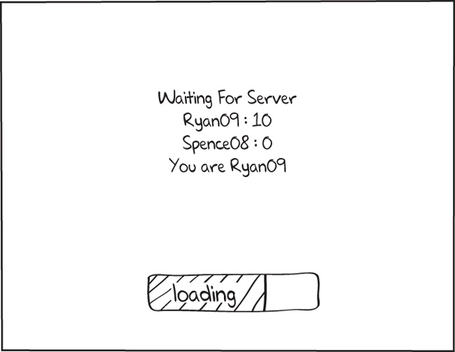

The remaining events concern messages from the server:

### client.rkt

```
(define (handle-appetizer-message s msg)
  (cond [(id? msg)    (app msg (app-img s) (app-countdown s))]
        [(time? msg)  (app (app-id s) (app-img s) msg)]
        [(state? msg) (switch-to-entree s msg)]
        [else s]))
```

As the protocol specifies, this function handles three messages. The first two `cond` clauses should be obvious. They just switch out one field with the newly arrived message. The third `cond` clause switches the client to the `entree` state. The last clause makes our message handling fault tolerant; it handles any violation of the agreed-upon protocol by ignoring the message and returning the current state. To make the program fault tolerant, the predicates that check our messages need to be programmed defensively. For example, here is the definition of `time?`:

### client.rkt

```
(define (time? msg)
  (and (real? msg) (<= 0 msg 1)))
```

It doesn’t just check whether the message is a number but also ensures that number is real and between `0` and `1`.

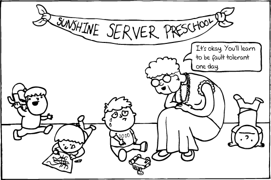

There is only one more function to deal with the `app` state. The function `switch-to-entree` is called when the first state message arrives. It consumes the current state and the state message, and it returns an `entree`:

### client.rkt

```
(define (switch-to-entree s m)
  (apply entree (app-id s) (rest m)))
```

Do you remember `apply`, the higher-order function introduced in Chapter 7? Go back and reread that section if you don’t. All `apply` does here is call the `entree` constructor on the current `id` and the remaining two elements of the state message, which just happen to make up the fields of an `entree`. Isn’t that easy? Time to eat.

### The Entree State

The `entree` state represents the client’s playing state. In this state, the player may interact with the world by clicking the screen to direct the avatar. The client displays the player’s avatar, all of the other avatars, and some information about each one in the rendering function `render-entree`:

### client.rkt

```
(define (render-entree entree)
  (define id (entree-id entree))
  (define pl (entree-players entree))
  (define fd (entree-food entree))
  (add-path id pl (add-players id pl (add-food fd BASE))))
```

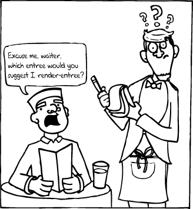

This function starts by drawing all of the food and players onto the base scene. It then draws the path of this client’s player. So let’s look at how players are drawn:

### client.rkt

```
(define (add-players id lof base-scene)
  (for/fold ([scn base-scene]) ([feaster lof])
    (place-image (render-avatar id feaster)
                 (feaster-x feaster) (feaster-y feaster)
                 scn)))
```

The `add-players` function consumes this client’s `id`, a list of all the players in the game, and a scene to add images on. The function uses `for/fold` to create a single image from the list of players. The given scene is used as the base case, and the function iterates over the given list of players. The loop creates an image with `render-avatar` and places it on the scene.

The `render-avatar` function creates an image of an avatar based on the client’s `id` and the `feaster` that represents the player to be drawn:

### client.rkt

```
(define (render-avatar id player)
  (define size (body-size (player-body player)))
  (define color
    (if (id=? id (player-id player)) MY-COLOR PLAYER-COLOR))
  (above
   (render-text (player-id player))
   (overlay (render-player-score player)
            PLAYER-IMG
            (circle size 'outline color))))
```

This function decides what color the avatar’s bounding circle should be, based on the given `id`. It then draws the bounding circle that has a radius based on the size of the given player. The actual avatar is placed at the center of the circle. By drawing the player’s avatar in this way, we have an accurate view of how large the avatar is, but we avoid pixelating the image by stretching it. We will leave it to you to write the rendering function that displays scores. The list of food is rendered in a similar fashion.

The last rendering step in the client concerns the path for this client’s avatar:

### client.rkt

```
(define (add-path id players base-scene)
  (define player
    (findf (lambda (x) (id=? id (player-id x))) players))
  (if (boolean? player)
      base-scene
      (add-waypoint* player base-scene)))
```

This function takes an `id`, a list of players, and an image to which the path is added. The function checks if this client’s `id` exists in the list of players. If it does not exist, then the `id` came from a spectator and no waypoints are drawn. Otherwise, it draws all the points for this client. This function is straightforward, so we leave it as an exercise for you.

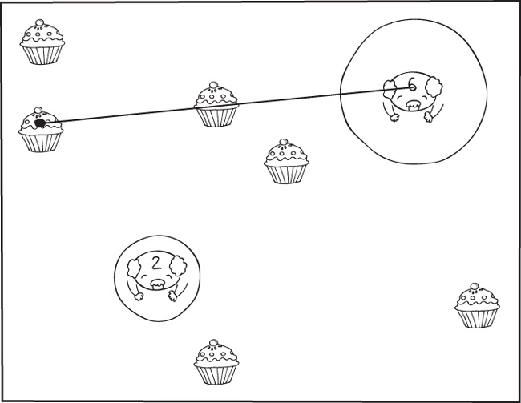

Finally, we deal with message handling for the `entree` state. The function for handling the messages in the `entree` state is similar to the message handler for the `app` state:

### client.rkt

```
(define (handle-entree-message s msg)
  (cond [(state? msg) (update-entree s msg)]
        [(score? msg) (restart s msg)]
        [else s]))
```

In the case of a state message, the handler calls `update-entree`, which works like `switch-to-entree`. In the case of a score message, the game restarts:

### client.rkt

```
(define (restart s end-msg)
  (define score-image (render-scores end-msg))
  (app (entree-id s) (above LOADING score-image) ZERO%))
```

This function builds an image that contains a table of all the scores and uses it as the base image for a new `app` structure. Building the table image is really easy as well:

### client.rkt

```
(define (render-scores msg)
  (define scores (sort (second msg) < #:key second))
  (for/fold ([img empty-image]) ([name-score scores])
    (define txt (get-text name-score))
    (above (render-text txt) img)))
```

Here, we take the list of scores and sort it in ascending order based on the second value of each list. If you want more detail about `#:key`, look up “keyword arguments” in the documentation. The function then iterates across this sorted list with `for/fold` and builds an image with the name and score, sticking it above the previous rows. And there you go. That’s the entire client.

## 14.7 Main, Take Server

Whenever we get to modules, we start with a main function, which is a `universe` function in the case of a game server:

### server.rkt

```
(define (bon-appetit)
  (universe JOIN0
            (on-new connect)
            (on-tick tick-tock TICK)
            (on-msg handle-goto-message)
            (on-disconnect disconnect)))
```

The initial state of the universe is a `join` state with no clients and some initial time.

The `on-new` clause deals with new connections:

### server.rkt

```
(define (connect s iw)
  (cond [(join? s) (add-player s iw)]
        [(play? s) (add-spectator s iw)]))
```

Like all `on-new` handlers, this function takes the current universe and an `iworld`, a piece of data representing the new connection. Once again, this event handler dispatches to auxiliary functions depending on the current state `s` of the universe. All of the `universe` handlers employ a similar strategy.

The function `disconnect` does exactly what it sounds like. It handles dispatch for disconnections:

### server.rkt

```
(define (disconnect s iw)
  (cond [(join? s) (drop-client s iw)]
        [(play? s) (drop-player s iw)]))
```

Just as before, this function determines the current state of the server and passes along its argument to the appropriate function.

Ticking works like this:

```
(define (tick-tock s)
  (cond [(join? s) (wait-or-play s)]
        [(play? s) (move-and-eat s)]))
```

In the `join` state, the function counts down and possibly transitions to the `play` state. In the `play` state, it moves all the players and lets them eat cupcakes. The `move-and-eat` function may also transition back to the `join` initial state if the last cupcake has been eaten.

The final universe clause we need to explain is `on-msg`. The `on-msg` handler clause is a little different from all of the others. Recall that the server accepts messages only when it is in the `play` state, and even then, there is only one kind of message that it accepts:

### server.rkt

```
(define (handle-goto-message s iw msg)
  (cond [(and (play? s) (goto? msg)) (goto s iw msg)]
        [else                        (empty-bundle s)]))
```

If the server is in the `play` state, and the message is a valid `GOTO` message, we add the new waypoint to the given player’s path. If not, then we do nothing, which in the case of a server, means we return a bundle with no messages, no dropped clients, and an unchanged state. It’s a really short function:

### server.rkt

```
(define (empty-bundle s)
  (make-bundle s empty empty))
```

The rest of the section explains how the server reacts to the network events and clock tick events, depending on which state it is in. Altogether, this makes four combinations. We start with a close look at how to handle network events while the server is in the `join` state.

### The Join State and Network Events

One network event signals the arrival of a new client. Think about this event and how we might handle it in the `join` state. Now think about how we might handle it in the `play` state. In both states, we must create a new internal player, add it to the state, and send the client its new `id`. The difference is that in the `join` state, we add the new internal player to the list of players, and in the `play` state, we add it to the list of spectators.

So let’s take advantage of these similarities with a little abstraction:

### server.rkt

```
(define (make-connection adder)
  (lambda (u iw)
    (define player (named-player iw))
    (define mails  (list (make-mail iw (ip-id player))))
    (make-bundle (adder u player) mails empty)))
```

This function consumes `adder`, a function that takes a state and a player and returns a state. Using `adder`, `make-connection` creates another function. This newly created function consumes a universe state and an `iworld`. It builds a new player, and it constructs mail for the new client that contains the guaranteed unique ID created with the new player’s name. The function returns this bundle.

This abstract function allows us to define the function to handle new clients for the `join` state in one line:

### server.rkt

```
(define (join-add-player j new-p)
  (join (cons new-p (join-clients j)) (join-time j)))

(define add-player (make-connection join-add-player))
```

The other part of the `make-connection` function we need is `named-player`:

### server.rkt

```
(define (named-player iw)
  (create-player iw (symbol->string (gensym (iworld-name iw)))))
```

It uses a fancy function, called `gensym`, to create a unique name that starts with the name of the client. Then it creates a player using `create-player`:

### server.rkt

```
(define (create-player iw n)
  (ip iw n (create-a-body PLAYER-SIZE) empty))
```

This creates a player with all the specified information, a body with some initial size, and an empty list of waypoints. The body of the player is placed at some random point on the playing field.

### Note

#|

The gensym function comes with all members of the Lisp family. It’s used to generate unique symbols that are not eq? to any other symbol in the entire program. You will learn more about why this facility is useful for writing programming languages in the next chapter. Here, we just use it for making unique names.

|#

Other than the arrival of new players, the server must also deal with player disconnections:

### server.rkt

```
(define (drop-client j iw)
  (empty-bundle (join-remove j iw)))
```

When a client is dropped, `drop-client` must find the player with the same `iworld` and remove it from the list of players. It does this using `join-remove`:

### server.rkt

```
(define (join-remove j iw)
  (join (rip iw (join-clients j)) (join-time j)))
```

The `rip` function finds the player with the given `iworld` and removes it from the list of clients. To do so, it uses the `remove` function, which we know from Chapter 6, but with a twist:

### server.rkt

```
(define (rip iw players)
  (remove iw players (lambda (iw p) (iworld=? iw (ip-iw p)))))
```

As this definition shows, `remove` is actually a higher-order function that takes an optional third argument for equality testing. By default, this function is `equal?`, but here we define “equality” to mean “having the same `iworld`” instead of “being exactly the same.” Why do you think we use `iworld=?` instead of the `equal?` function?

### The Join State and Tick Events

Dealing with tick events requires a complex handler. It all starts with `wait-or-play`:

### server.rkt

```
(define (wait-or-play j)
  (cond [(keep-waiting? j) (keep-waiting j)]
        [else              (start-game j)]))
```

As the name says, this function either continues waiting or transitions into the `play` state.

Checking whether or not to transition works as follows:

### server.rkt

```
(define (keep-waiting? j)
  (or (> PLAYER-LIMIT (length (join-clients j)))
      (> WAIT-TIME (join-time j))))
```

The server waits if there are not enough players for a good game or if the allotted wait time is not up. It’s equally easy to define `keep-waiting`:

### server.rkt

```
(define (keep-waiting j)
  (set-join-time! j (+ (join-time j) 1))
  (time-broadcast j))
```

All that’s necessary is to increment the time and send that new time to all clients, which the following function accomplishes:

### server.rkt

```
(define (time-broadcast j)
  (define iworlds (map ip-iw (join-clients j)))
  (define load% (min 1 (/ (join-time j) WAIT-TIME)))
  (make-bundle j (broadcast iworlds load%) empty))
```

The key is the call to `broadcast`. This helper will be used in a number of places to send a message to all clients. It takes a list of `iworld`s and the message to be sent, which in this case is a percentage of the current time. It returns a list of `mail`s, one for each client.

Let’s take a look at the `broadcast` function:

### server.rkt

```
(define (broadcast iws msg)
  (map (lambda (iw) (make-mail iw msg)) iws))
```

With `map`, this function definition becomes downright trivial. We show it only because it is used in almost every function that sends a message from the server to the clients.

Now it is time to look at how the server starts a game:

### server.rkt

```
(define (start-game j)
  (define clients (join-clients j))
  (define cupcakes (bake-cupcakes (length clients)))
  (broadcast-universe (play clients cupcakes empty)))
```

The `start-game` function takes a `join` state and creates a `play` state. This `play` universe starts with the list of players from the `join` universe, a list of food, and an empty list of spectators. Using `broadcast-universe`, we send this initial state to all of the clients. We generate a number of cupcakes that is directly proportional to the number of players:

### server.rkt

```
(define (bake-cupcakes player#)
  (for/list ([i (in-range (* player# FOOD*PLAYERS))])
    (create-a-body CUPCAKE)))
```

We chose to generate cupcakes in this fashion, but you can define this function in whatever way you want. Take note that we use the `create-a-body` function.

Onwards to the `broadcast-universe` function:

### server.rkt

```
(define (broadcast-universe p)
  (define mails (broadcast (get-iws p) (serialize-universe p)))
  (make-bundle p mails empty))
```

Here, we reuse the `broadcast` function to create a state message for each of the clients. As usual, this function returns a bundle with the universe and the list of mail that needs to be sent. While `get-iws` is another easy little function that you should be able to write yourself, `serialize-universe` is a little trickier:

### server.rkt

```
(define (serialize-universe p)
  (define serialized-players (map ip-player (play-players p)))
  (list SERIALIZE serialized-players (play-food p)))
```

Remember that `ip`s contain complete `player`s and that these are represented with prefab structures. As planned, we can send those across the network, and that’s what we do. With that, we are finished with the `join` state for the server.

### The Play State and Network Events

Now our server can reach the `play` state. It is time to think about how the `play` state should handle network events. As with the `join` state, we start with handling new connections, which are added as spectators. Recall that we have already dealt with new connections for `join` states and that we created an abstraction for dealing with them.

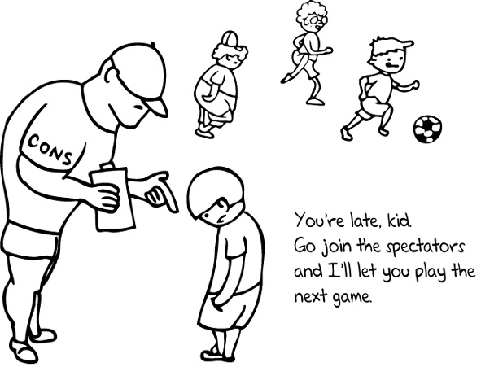

Having said that, here is `play-add-spectator`, which `cons`es the new client onto the list of spectators.

### server.rkt

```
(define (play-add-spectator pu new-s)
  (define players (play-players pu))
  (define spectators (play-spectators pu))
  (play players (play-food pu) (cons new-s spectators)))

(define add-spectator (make-connection play-add-spectator))
```

The next network event concerns the arrival of `GOTO` messages, which are the only ones that the server deals with:

### server.rkt

```
(define (goto p iw msg)
  (define c (make-rectangular (second msg) (third msg)))
  (set-play-players! p (add-waypoint (play-players p) c iw))
  (broadcast-universe p))
```

First, `goto` creates a complex number representing the new waypoint. Second, it modifies the current list of players with that waypoint added to the client who sent the message. Finally, it broadcasts the new state of the universe. This broadcast allows the client to see that its waypoint message was accepted and to draw an appropriate path. Indeed, all clients get to see the new waypoint, and that may concern you.

The only undefined auxiliary function in `goto` is `add-waypoint`:

### server.rkt

```
(define (add-waypoint ps c iw)
  (for/list ([p ps])
    (cond [(iworld=? (ip-iw p) iw)
           (ip (ip-iw p)
               (ip-id p)
               (ip-body p)
               (append (ip-waypoints p) (list c)))]
          [else p])))
```

This function traverses the given list of players, and when it finds the player with an `iworld` matching the one that sent the new waypoint, it reconstructs the given player, adding the provided complex number to the end of its list of waypoints.

The last kind of network event to worry about is a client disconnection:

### server.rkt

```
(define (drop-player p iw)
  (broadcast-universe (play-remove p iw)))
```

Disconnecting from the `play` universe is like disconnecting from the `join` universe with the difference that we broadcast the new state to all players so that they know some client has dropped out. The `play-remove` function has a straightforward definition:

### server.rkt

```
(define (play-remove p iw)
  (define players (play-players p))
  (define spectators (play-spectators p))
  (play (rip iw players) (play-food p) (rip iw spectators)))
```

The only difference between `join-remove` and `play-remove` is that the latter uses `rip` on both `players` and `spectators` because we don’t know whether a player or a spectator has dropped out.

### The Play State and Tick Events

We have one server handler left to deal with: the clock-tick handler. It is a large one because this function deals with all the game logic. We start with `move-and-eat`:

### server.rkt

```
(define (move-and-eat pu)
  (define nplayer (move-player* (play-players pu)))
  (define nfood (feed-em-all nplayer (play-food pu)))
  (progress nplayer nfood (play-spectators pu)))
```

For doing so much, this three-line function definition looks almost trivial, but bear with us—it gets a little complicated. First, `move-and-eat` uses `move-player*` to move the players in the appropriate direction at an appropriate speed. Second, a new list of food is generated that doesn’t contain any cupcakes that a player has eaten. The function `feed-em-all` also mutates the bodies of players who are eating; remember that they grow in size. Finally, these two lists, along with the list of spectators, are sent to the `progress` function. It will either progress the game by sending the new `play` state to all clients or transition to a `join` state by sending out the final score message.

Here is how we move all the players:

### server.rkt

```
(define (move-player* players)
  (for/list ([p players])
    (define waypoints (ip-waypoints p))
    (cond [(empty? waypoints) p]
          [else (define body (ip-body p))
                (define nwpts
                  (move-toward-waypoint body waypoints))
                (ip (ip-iw p) (ip-id p) body nwpts)])))
```

For every player with waypoints, we mutate the player’s body with `move-toward-waypoint`. If the player reaches her first point, `move-toward-waypoint` chops off the first waypoint and returns the new list. If the next waypoint has not been reached, the list remains the same. A player without waypoints is left unchanged.

Moving individual players takes a bit of tricky math, but using complex numbers makes our lives pretty easy:

### server.rkt

```
(define (move-toward-waypoint body waypoints)
  (define goal (first waypoints))
  (define bloc (body-loc body))
  (define line (- goal bloc))
  (define dist (magnitude line)) ;;in pixels per clock tick
  (define speed (/ BASE-SPEED (body-size body)))
  (cond [(<= dist speed)
         (set-body-loc! body goal)
         (rest waypoints)]
        [else ; (> dist speed 0)
         (define velocity (/ (* speed line) dist))
         (set-body-loc! body (+ bloc velocity))
         waypoints]))
```

The main part of the function is the conditional block. It checks the distance the player moves in this tick. If this condition is satisfied, the function sets the location to the goal to avoid overshooting it. Then, the function returns the rest of the waypoints. Otherwise, we add `velocity` to the current location, where `velocity` is the fraction of the complex number by which the body should move toward the next waypoint. Also notice that `speed` depends on the size of the body, meaning that a player’s body slows down as it gets bigger.

If this looks to you like a bunch of complicated vector math, hidden behind complex arithmetic, then you’re right. We recommend that you browse the Web for more information on vector-based movement. You should admire, however, how this avoids all uses of `sin`, `cos`, and other trigonometry.

Now think about the `ip` structure for a moment. Don’t we have an internal `player` that needs updating? No, we don’t. We got away with this because `body` in the `ip` and `player` structure is the *same* body, so mutating one mutates the other. Because they are really `eq?`, no extra modifications are needed.

It is time to feed the players. We start with `feed-em-all`:

### server.rkt

```
(define (feed-em-all players foods)
  (for/fold ([foods foods]) ([p players])
    (eat-all-the-things p foods)))
```

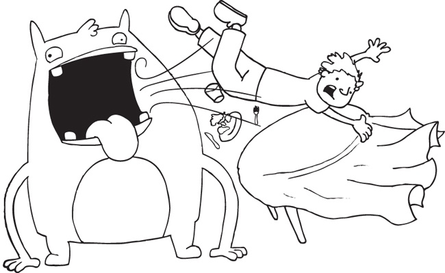

This function folds across the players, accumulating a new list of food by removing any food that a player collides with. The function `eat-all-the-things` is the workhorse here, filtering out the eaten cupcakes and face-stuffing players:

### server.rkt

```
(define (eat-all-the-things player foods)
  (define b (ip-body player))
  (for/fold ([foods '()]) ([f foods])
    (cond
      [(body-collide? f b)
       (set-body-size! b (+ PLAYER-FATTEN-DELTA (body-size b)))
       foods]
      [else (cons f foods)])))
```

This function also uses `for/fold`, but this time, it folds across the list of cupcakes. If the current food collides with the given player, it is not accumulated; instead, the player is fattened. Otherwise, the food is put back in the list.

The collisions themselves are straightforward:

### server.rkt

```
(define (body-collide? s1 s2)
  (<= (magnitude (- (body-loc s1) (body-loc s2)))
      (+ (body-size s1) (body-size s2))))
```

This function compares the distance between the centers of the two bodies with the sum of their sizes. If the distance is less than the combined radius, then it must be a collision. And that’s it.

Finally, we must discuss the `progress` function:

### server.rkt

```
(define (progress pls foods spectators)
  (define p (play pls foods spectators))
  (cond [(empty? foods) (end-game-broadcast p)]
        [else (broadcast-universe p)]))
```

If all cupcakes have been eaten, `progress` ends the game by transitioning to a `join` state and sending the score list to all clients. If not, it just uses `broadcast-universe` to send out the current state.

Ending the game is simple:

### server.rkt

```
(define (end-game-broadcast p)
  (define iws (get-iws p))
  (define msg (list SCORE (score (play-players p))))
  (define mls (broadcast iws msg))
  (make-bundle (remake-join p) mls empty))
```

All that happens here is that we build a score message, broadcast it to all players, and create a new `join` state from the current players and spectators. To accomplish this, we need the `score` function, which builds an association list linking each player’s `id` to her score:

### server.rkt

```
(define (score ps)
  (for/list ([p ps])
    (list (ip-id p) (get-score (body-size (ip-body p))))))
```

In truth, this function builds the second half of the score message. In order for the client to recognize this message, it needs to be placed in a list with `SCORE` as the first element. But the only part of this function that might be a little tricky is getting a player’s score from its weight. Recall that a player’s weight is increased by some amount whenever it eats. Hence, its weight is directly proportional to the number of cupcakes eaten:

### shared.rkt

```
(define (get-score f)
  (/ (- f PLAYER-SIZE) PLAYER-FATTEN-DELTA))
```

We leave the explanation of this math up to your grade school math teacher.

Last, but not least, we turn our eyes to the `remake-join` function. Given a `play` state, this function constructs a new `join` state:

### server.rkt

```
(define (remake-join p)
  (define players (refresh (play-players p)))
  (define spectators (play-spectators p))
  (join (append players spectators) START-TIME))
```

To do this, we refresh the current list of players. This moves them to a new location with an unfattened body. This list is joined with the spectators list to make the list of clients for the new state. Add `START-TIME` to the new `join` state to get the countdown going, and you have a complete new `join` state.

## 14.8 See Henry Run

The game is complete, but we need to see it run so that we can correct problems that unit tests don’t uncover. While it is possible to run the game with the existing code, doing so is cumbersome—politely put. If we write a bit of extra code, life becomes easy.

As in the preceding chapter, let’s create a new file to run the game and require all necessary pieces into this fourth file:

### run.rkt

```
#lang racket
(require (only-in "server.rkt" bon-appetit)
         (only-in "client.rkt" lets-eat)
         2htdp/universe)
```

The `require` specification tells Racket to include one function from **server.rkt** and another one from **client.rkt**, plus everything that **2htdp/universe** provides.

With these functions, we define `serve-dinner`, launching a server and two clients:

### run.rkt

```
(define (serve-dinner)
  (launch-many-worlds (bon-appetit)
                      (lets-eat "Matthias" LOCALHOST)
                      (lets-eat "David"    LOCALHOST)))
```

And bam! We can play the game just by running one simple function. It doesn’t even take any arguments. With this last file, the game is complete. Go play.

## `On-disconnect`—Chapter Checkpoint

In this chapter, we created an interesting distributed multiplayer game:

- Distributed programming requires a planned-out communication protocol. Ours fits into a one-page diagram.
- Designing a good protocol can save you a lot of work. Spend time on it.

## Chapter Challenges

- **Easy**. Modify the game so that new cupcakes appear on the screen every other time one is eaten.
- **Medium**. Right now, a clever player could write a client that takes advantage of the other player’s waypoints. Modify the data protocol so that this security breach cannot happen.
- **Difficult**. Write an AI that follows the modified protocol.

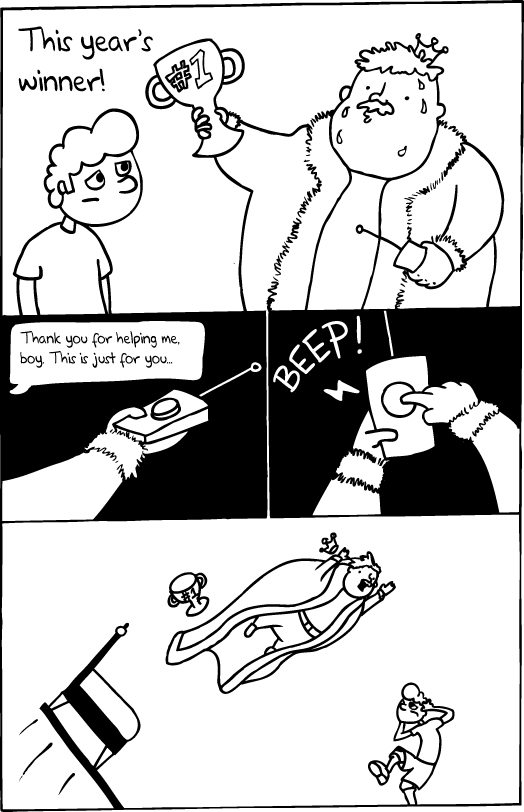

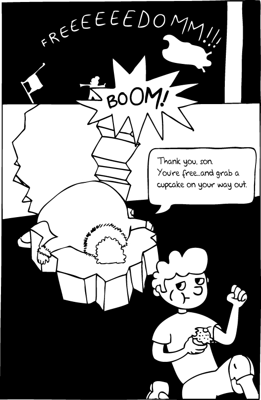

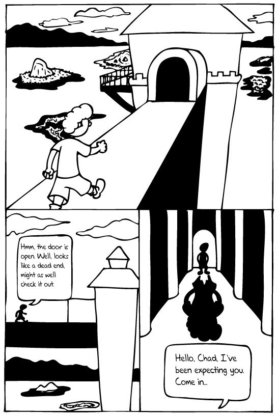

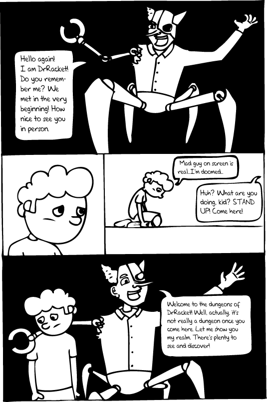

## Conclusion. Good-Bye (Close Paren)

#|

This book only scratches the surface of Racket. In this chapter, we will give you a glimpse of what else you can find in the depths of Racket: realms of unique and powerful programming ideas. We hope you find the ideas intriguing and will continue to explore Racket. If you need help, Help Desk and the Racket users mailing list are there for you.

|#

## ).1 Run Racket Run

Due to some old, silly tradition, most books on programming languages start with a program that prints “Hello, world.” You may think we missed our chance, but here we go:

```
"Hello, world."
```

This is the entire program. No command for printing is needed. Racket knows what to do. Yes, you need to tell the Racket implementation that you’ve written the program in one of its many dialects:

```
#lang racket/base
"Hello, world."
```

Click “Run,” and you will see that it really prints `"Hello, world."` in the interactions panel. Did you notice that the `#lang` line looks different? Don’t worry about this for now, but rest assured that you will see many different `#lang` lines before this chapter is over.

“Wait!” you might object, “In real programming languages, you write programs that run from the command line. People shouldn’t have to open a development environment to run their programs.” Don’t worry; be happy. In Racket you can do this, too. Save the file as **hello-world.rkt**, open a command shell, go to the folder where you saved the program, and enter this:

```
$ racket hello-world.rkt
```

Ta-da! The string `"Hello, world."` appears. Your first program is complete.

But maybe you’re starting to worry that your grandmother wouldn’t know she has to type `racket` to run the program, right? You are too easily worried. Here’s what you do.

Go back to your command shell and run these commands:

```
$ raco exe -l hello-world.rkt
$ ./hello-world
```

And eureka, once again you see the magical words. No one will know from the name of the file or the command line that you are using Racket. From now on, it’s your secret weapon.

In case you’re wondering, `raco exe -l` creates an executable script from a Racket program on all platforms: Windows, Mac OS X, and all *nixes. For the name of the script, it removes the `.rkt` suffix so that no one knows it was created from a Racket program.

There is much more to learn about running Racket programs, but we need to move on. Read the documentation if you need more information. Also, check DrRacket’s “Racket” menu for the “Create Executable” item.

## ).2 Racket Is a Programming Language

If you have learned programming in the past 20 years or so, chances are that you grew up with classes, fields, and methods. And if so, you may be wondering whether Racket is the only language that comes without classes. We admit that many of our game programs would benefit from classes, but we wanted to show you a programming style so light and so simple that your little brother in high school could see how to do it. It is the style that makes mathematics come alive.

Racket is a regular programming language, and as such, it does come with classes and objects. For example, the snakes from Chapter 6 could be presented as a short class in a rather compact way:

```
(define snake%
  (class object%
    (super-new)
    (init-field dir head tail)

    (define/public (slither)
      (set! tail (cons head (all-but-last tail)))
      (set! head (next-head)))

    (define/public (grow)
      (set! tail (cons head tail))
      (set! head (next-head)))

    (define/public (can-eat goos)
      (findf (lambda (goo) (close? goo head)) goos))

    (define/private (next-head)
      (cond
        [(string=? dir "up")    (posn-move head  0 -1)]
        [(string=? dir "down")  (posn-move head  0 +1)]
        [(string=? dir "left")  (posn-move head -1  0)]
        [(string=? dir "right") (posn-move head +1  0)]))))
```

Like the original game, this class supports the most basic snake actions: slithering, growing by one segment, and checking whether some food is in close proximity. Technically, the class says that it is a subclass of `object%`; that it has three fields, which are also initial parameters; and that it comes with three public methods and one private one.

Here is the conventional way to create an instance of this class:

```
(define snake1
  (make-object snake% "left" (posn 1 2) '()))
```

As in Java, this expression creates an instance by passing in the three required initialization arguments. When a class has three initialization arguments, you might remember the order in which you need to pass the arguments to the constructor. But even then, it is better to say which argument populates which field, and in Racket, you can do so easily:

```
(define snake2
  (new snake% [head (posn 3 9)] [tail '()] [dir "up"]))
```

With this second method of object instantiation, you can clearly see which fields you are initializing in what way.

It shouldn’t come as a surprise that you can extend Racket classes and that doing so looks like it does in any pedestrian programming language:

```
(define snake-render%
  (class snake%
    (super-new)
    (inherit-field dir head tail)

    (init-field [bgrd THE-EMPTY-SCENE] [img-db "image-file"])

    (define/public (render)
      (define head-img (select-head dir img-db))
      (define tail-img (img-list+scene tail SEG-IMG bgrd))
      (img+scene head head-img tail-img))))
```

Note how this class definition explicitly specifies which fields it inherits; we will explain why in a moment. More importantly, the class has two optional initialization arguments, which you may or may not supply when you create instances:

```
(define snake3
  (new snake-render% [dir "down"] [head (posn 4 3)] [tail '()]))

(define snake4
  (new snake-render% [dir "down"] [head (posn 4 3)] [tail '()]
       [img-db "new-image-file"]))
```

If you now think Racket classes are as boring as the ones you got to know in your favorite object-oriented language, you are gravely mistaken. In most languages, objects are values, and this is true in Racket as well. But in Racket, classes are values, too, just like numbers, Booleans, or functions. You already know that having functions as values is a powerful concept. You should have no doubts that having classes as values is an equally powerful idea.

Let’s start with a couple of silly examples:

```
(define snake5
  (new (if (today-is-tuesday?) snake% snake-render%)
       [dir "down"] [head (posn 4 3)] [tail '()]))
```

The first one demonstrates that wherever an expression needs a class, it is acceptable to write an expression that evaluates to a class. In this case, the result is a snake with the render method on all days except for Tuesdays. You’ll have a hard time doing this in Java, no matter what day of the week it is.

This second example shows the same idea in a different context:

```
(define some-snake%
  (class (if (today-is-sunday?) snake% snake-render%)
    (super-new)))
```

Yes, even the superclass of a class can be determined at runtime, as long as the expression in this position returns a class.

A somewhat more serious example is a function that consumes and produces a class:

```
(define (add-render %)
  (class %
    (super-new)
    (inherit-field dir head tail)
    (init-field [bgrd THE-EMPTY-SCENE])

    (define/public (render)
      (define head-img
        (cond
          [(string=? "up" dir)    HEAD-UP-IMG]
          [(string=? "down" dir)  HEAD-DOWN-IMG]
          [(string=? "left" dir)  HEAD-LEFT-IMG]
          [(string=? "right" dir) HEAD-RIGHT-IMG]))
      (define tail-img (img-list+scene tail SEG-IMG bgrd))
      (img+scene head head-img tail-img))))
```

Take a look at the function parameter. It is `%`, which is the Racketeering convention for saying that this function expects a class as an argument. Once the function is applied to some class, say, `snake%`, it constructs a class extension from it:

```
(define snake-render-again%
  (add-render snake%))
```

It does so by first checking that the given class has three fields: `dir`, `head`, and `tail`. The superclass is forced to have these fields because we require them with `inherit-field`. Next, it creates an extended class with a render method, more or less the way `snake-render%` does.

The best aspect is that if you wish to introduce renderable crocodiles into the Snake game, you can easily do so:

```
(define crocodile%
  (class object%
    (init-field dir head tail)
    ...))
```

Adding the render method would be a two-line definition:

```
(define crocodile-render
  (add-render crocodile%))
```

In other words, functions such as `add-render` allow a programmer to dynamically splice entire classes into the class hierarchy.

Cool, right? What is even better is that the class system isn’t a part of the Racket core. It is really shorthand for structures and functions, though you’d never know. The trick is called a macro, and we will explain macros next.

## ).3 Racket Is a Metaprogramming Language

All members of the Lisp family come with incredibly powerful ways to add new syntax to the language. For better or worse, pedestrian programmers call this idea metaprogramming, and Lispers say **macro programming**. Regardless of what you call them, macros allow you to expand the vocabulary of your language.

Racket comes with the most expressive and powerful macro system of them all. No other Lisp even comes close. Here, we provide you a glimpse of these magical macros.

We start with a definition for adding `and`-like expressions:

```
(define-syntax-rule
  (my-and a b)
  (if a b #f))
```

The advantage of re-implementing existing expressions is that we can compare our work with Racket’s version to see whether we’re on the right track. The definition of `my-and` tells Racket that whenever it encounters an expression of the form `(my-and a b)`, it rewrites the expression to `(if a b #f)`. This `if` expression truly computes the `and`-like composition of `a` and `b`. Let’s try it out in the interactions panel:

```
> (my-and (< 10 11) (< 11 12))
#t
> (my-and (< 10 11) 'ready!)
'ready!
> (my-and (> 10 11) (+ (/ 1 0) 10))
#f
```

The last two interactions show how closely `my-and` mimics `and`. First, it evaluates to more than plain Boolean values. Second, it shortcuts the evaluation of its subexpressions so that the division by 0 never gets to signal an error.

This last point also explains why it is impossible to define `my-and` as a plain function. If you were to try, you would quickly realize that an application of a `my-and` function forces all arguments to be evaluated *before* the function has a chance to break out of the sequence when an `#f` shows up. Put differently, if `my-and` had been defined as a function, the last interaction would signal an error concerning the division by `0`.

If we now asked you to re-create `or` with a macro, you would probably come up with something like this:

```
(define-syntax-rule
  (my-or a b)
  (if a a b))
```

It is close enough for government work, which the following interactions show:

```
> (my-or (> 10 11) (< 10 11))
#t
> (my-or (< 10 9) 'okay)
'okay
> (my-or (< 9 10) (+ (/ 1 0) 10))
#t
```

We will let you figure out why the results are as expected. It should worry you, however, that Racket is told to duplicate `a` when it encounters `(my-or a b)` in your program. The result, `(if a a b)`, seems to compute whether `a` or `b` evaluates to true, but it does so by reevaluating `a` when `a` produces true. This reevaluation is acceptable for a simple `a`, but it isn’t innocent:

```
> (my-or (begin (displayln "hello world") 'okay) #f)
hello world
hello world
'okay
```

If `a` prints a string, then that printing is performed twice. But with `or`, we don’t get this kind of double execution:

```
> (or (begin (displayln "hello world") 'okay) #f)
hello world
'okay
```

Amazingly, `or` just knows that `a` produced a true value, and it returns that value.

Now it is time to remind you of `let` expressions. Even though they have played only a minor role so far, many macros use them extensively. So take a look at this:

```
>  (let ((temp (* 2 2))) (+ temp temp temp))
12
```

A `let` expression evaluates expressions such as `(* 2 2)` and names the resulting value, `temp`. The body of our `let` expression is `(+ temp temp temp)`, meaning it adds `temp` three times, and that is how we get `12`.

Here is another variant of this `let` expression:

```
> (let ([temp (begin (displayln "H")
                     (+ 2 2))])
    (+ temp temp temp))
H
12
```

As you can see, `temp` really stands for `4` and `displayln` is run only once. And now we will take a second look at an `or`-style macro definition:

```
(define-syntax-rule
  (your-or a b)
  (let ((temp a)) (if temp temp b)))
```

This macro says evaluate `a`, name the value `temp`, and then test whether `temp` stands for true. If so, return `temp`, meaning the value that this name represents. And voilà, you get what you expect:

```
> (your-or (begin (displayln "hello world") (> 10 9)) temp)
hello world
#t
```

The printing is no longer duplicated in this version of `or`.

At this point, you may wonder whether the `temp` inside `let` could interfere with variables that show up in `a` or `b`. Suppose we define another `temp` with a `define` in the interactions panel:

```
> (define temp 'okay)
```

When Racket now encounters `(your-or (> 10 19) temp)`, it is supposed to replace it with `(let ((temp (> 10 19))) (if temp temp temp))`. But if it did so, `(your-or (> 10 19) temp)` would evaluate to `#f`, and that contradicts what we expect from an `or`-style macro. With `or`, you should expect to get `'okay` back because `(> 10 19)` evaluates to false, but `temp` just stands for `'okay,` and that is true.

Fortunately, Racket knows how to separate the variables that show up in macro definitions from those that show up in macro uses, so everything works out fine:

```
> (your-or (> 10 19) temp)
'okay
```

We don’t have the space here to explain how Racket accomplishes this feat. You just need to know that it uses the `gensym` function mentioned in Chapter 14. And therefore, you can write macros that work.

Before we move on, let’s show you one more macro definition for a regular Racket form. Since we have just reminded you of `let`, we thought we’d show you its essence:

```
(define-syntax-rule
  (my-let.v1 name initial-value-exp body)
  ((lambda (name) body) initial-value-exp))
```

This first version of the macro can introduce one variable, initialize it to a value, and evaluate a `body` expression in which the variable may occur as many times as needed. Here is a simple use of the macro:

```
> (my-let.v1 x 10 (+ x 19))
29
```

The key is that Racket’s functions are plain values, and you can make one up on the fly. In this case, the macro makes up a function whose sole parameter is the newly introduced variable `x` and whose body is a subexpression from the `my-let.v1` expression. By applying this function to the expression that is supposed to initialize the variable, the macro evaluates `body` in a world where `name` stands for the value of `initial-value-exp`, and that is exactly what `let` promises to do.

Racket’s `let`, though, is far more flexible than `my-let.v1`. In particular, `let` empowers programmers to define several variables at once. With macros, it is possible to mimic this behavior, too:

```
(define-syntax-rule
  (my-let.v2 ((name initial-value-exp) ...) body)
  ((lambda (name ...) body) initial-value-exp ...))
```

This definition may not look real to you because of all the occurrences of ... in the input and output pattern. But Racketeers really describe many macros by example. This one translates as follows:

```
(my-let.v2 ((a b)) yyy) to ((lambda (a) yyy) b),
(my-let.v2 ((a b) (c d)) yyy) to ((lambda (a c) yyy) b d), and
(my-let.v2 ((a b) (c d) (e f)) yyy) to ((lambda (a c e) yyy) b d f).
```

In other words, in the first line of the macro definition, the dots stand for “zero or more occurrences of the preceding *S*-expression pattern,” and in the second line, they mean “whatever you saw when you matched that pattern.” And it really works:

```
> (my-let.v2 ((x 1) (y 2)) (+ x y))
3
> (my-let.v2 ((x 1) (y 2) (z 3) (w 4) (u 5)) (+ x y z w u))
15
```

Indeed, it even works when we do not define any temporary variables:

```
> (my-let.v2 () 55)
55
```

What you have seen so far is the most trivial form of defining macros. At this point, you can’t fortify your macros against the most basic misuses. Even with these trivial macros, however, you could create a simplistic, albeit difficult to use, class system. Better still, these simple macros suffice to create programming languages from scratch, and doing so is as easy as writing a module.

## ).4 Racket Is a Programming-Language Programming Language

Many computational problems require substantial knowledge about the problem area, also known as the **domain**. For example, dealing with time series from medical trials calls for a statistician who is familiar with medical procedures and Bayesian mathematics. Similarly, the core of an engineering system may rely on a module that deals with system-specific partial differential equations. When programmers express solutions to these problems with classes, methods, and `for` loops, experts have a difficult time communicating with them. Experts would much prefer to articulate solutions in a language that they understand, even if the language is just a special-purpose programming language from our perspective.

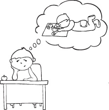

Racket makes it particularly easy to create new programming languages, including special-purpose languages. The goal of this section is to provide you with a taste of language engineering. We want to show you how easy it is to engineer languages, and we hope you will find this idea intriguing and interesting enough to check out the documentation.

When a module defines a macro, other expressions and definitions in the module can use this syntactic abbreviation right away. If the module also provides the macro, other modules can require the module and use the macro, too. To create an entire language, a Racketeer has to change just one step of this procedure: the providing module must be used as the language name of the module. Here is how this is done:

```
#lang s-exp "silly-lang.rkt"
```

Stop! This module is the first one in this book that does not specify `racket` or `racket/base` as the name of the language. Instead, it uses `s-exp`, which then expects a path to a file that implements the actual language.

### Note

#|

It is also possible to get rid of s-exp and to use the name of a folder as the name of a programming language, which is what Racket does. We do not have room in this book to explain the second variant of making languages. If you are interested, see the Racket documentation.

|#

Like a compiler, the macros translate programs from the new language to plain Racket. If these generated Racket programs need functions or other values when they are run, the module supports these, too. Following traditional terminology, we call these the **runtime** system.

Now consider the following definitions:

### silly-lang.rkt

```
#lang racket

(define-syntax-rule
  (count-and-print f)
  (begin (count++ 'f) f))

(define count 0)
(define (count++ f)
  (set! count (+ count 1))
  (displayln `(evaluating form ,count : ,f)))
```

When Racket encounters `(count-and-print (+ 1 1))`, this macro definition tells it to use `(begin (count++ '(+ 1 1)) (+ 1 1))` instead. Recall that a quote in front of an expression turns it into a list. Hence, `count++` is not applied to `2` but to `(list '+ 1 1)`. The call to `count++` bumps the `count` variable and uses this number to remind the programmer how many expressions have been evaluated. It also displays the expression that is about to be evaluated.

### Note

#|

See how ` and , work together to tell the quote expression to use the actual values of count and f? For more information, look up quasiquote, unquote, and unquote-splicing in the documentation.

|#

Here are some sample uses from the interactions panel:

```
> (count-and-print (+ 1 1))
(evaluating form 1 : (+ 1 1))
2
> (count-and-print (+ 1 2))
(evaluating form 2 : (+ 1 2))
3
```

Now you may be wondering why we bother with such a silly macro.

Imagine running a long definitions window and all the definitions and expressions it evaluates. Wouldn’t it be nice if the interactions panel told you where the results came from? It is possible to implement this change easily by defining a language.

At a minimum, a language is a module that provides some key forms. The most important one is a form that tells Racket how to deal with the content of a module in the new language. Others are about dealing with function applications and data.

Languages provide three common forms:

- `#%module-begin`, which is a form like `begin` that is implicitly wrapped around the content of an entire module
- `#%app`, which is implicitly wrapped around each function application
- `#%datum`, which is implicitly wrapped around each occurrence of a literal piece of data

Otherwise, the module must provide everything else the language is supposed to have.

Given that much, we know how to turn our macro into a useful device. First, we define a macro that wraps `count-and-print` around every form in the new language:

### silly-lang.rkt

```
(define-syntax-rule
  (module-count-and-print f ...)
  (#%module-begin (count-and-print f) ...))
```

Here, `#%module-begin` refers to the macro that `silly-lang.rkt` requires from the `racket` language. Second, we provide this macro with the name `#%module-begin`:

### silly-lang.rkt

```
(provide (rename-out [module-count-and-print #%module-begin])
         #%app #%datum +)
```

Furthermore, we provide Racket’s way of interpreting function application and literal data constants, plus the addition function.

And that is all there is to the creation of a new language. Save the file. Get ready.

Here is the experiment you want to conduct now. Create the file **silly.rkt** like this:

### silly.rkt

```
#lang s-exp "silly-lang.rkt"
(+ 2 3)
(+ 4 -1)
```

Save it in the same directory as the **silly-lang.rkt** file and click “Run.” The output in the interactions panel looks like this:

```
(evaluating form 1 : (+ 2 3))
5
(evaluating form 2 : (+ 4 -1))
3
```

This is precisely what we wanted. But the interactions panel also says that it is no longer possible to interact with poor DrRacket.

Here is the reason for DrRacket’s inability to interactively evaluate expressions in this language. If you want or need interactivity from a language, it must provide another form, one that deals with expressions at the interactions prompt: `#%top-interaction`. This form is implicitly wrapped around each and every form you enter at the prompt. If you wanted the interactions panel of the **silly-lang.rkt** language to evaluate forms like Racket, the file should provide `#%top-interaction` from Racket. If you wanted the interactions panel to continue counting your evaluations, you would have to define a macro that knows how to use `count++`:

### silly-lang.rkt

```
(define-syntax-rule
  (interact-count-and-print . f)
  (count-and-print f))
```

Similarly, if your language needs to use `define`, just provide it; Racket makes it available. Indeed, you can easily provide everything from Racket with a simple `provide` clause:

### silly-lang.rkt

```
(provide
  (rename-out [module-count-and-print #%module-begin])
  (rename-out [interact-count-and-print #%top-interaction])
  (except-out (all-from-out racket)
              #%module-begin #%top-interaction))
```

This last clause says make **silly-lang.rkt** like Racket except for two features, which are exported separately. Of course, as indicated with the first version of **silly-lang.rkt**, there doesn’t need to be much or any overlap with Racket at all; `+` was all we needed to get going.

Let’s look at another example of a Racket-made programming language:

### delayed-lang.rkt

```
#lang racket
(provide
   (rename-out [delayed-args-app #%app])
   #%datum #%module-begin #%top-interaction
   define if force* (rename-out [+force +] [/force /]))

(define-syntax-rule
  (delayed-args-app f a ...)
  (#%app f (delay a) ...))

(define (+force a b)
  (+ (force* a) (force* b)))

(define (/force a b)
  (/ (force* a) (force* b)))

(define (force* x)
  (if (promise? x) (force* (force x)) x))
```

The first definition is the most interesting one. It tells Racket to rewrite all occurrences of this code:

```
(delayed-args-app a b c) to (#%app a (delay b) (delay c))
```

As we alluded to before, `#%app` is how Racket sees every function application, and this occurrence of `#%app` refers to the way the Racket language applies functions. The trick is that `delayed-args-app` is provided as the *new* `#%app` in the first line of the module, meaning every function application in a requiring module is rewritten in this manner.

The other definitions introduce functions: a `+force` function, which forces its arguments and adds the results; a `/force` function, which is like `+force` but for `/`; and `force*`, which calls `force` on its argument until it isn’t a promise. The first two functions are provided as `+` and `/`, respectively, and the last one on an as-is basis. Other than that, the module provides the usual suspects, as well as `define` and `if`.

### delayed.rkt

```
#lang s-exp "delayed-lang.rkt"

(define (f x)
  (+ 1 x))
(f (/ 4 2))
```

### delayed.rkt

```
(define (g y)
  2)
(g (/ 1 0))
```

Now if you run this module, you see `2` printed. Why? When Racket encounters this . . .

```
(g (/ 1 0))
```

. . . it uses `#%app` from the language module, which means `(g (/ 1 0))` is rewritten as . . .

```
(#%app g (delay (/ 1 0)))
```

This second `#%app` is taken from the `racket` language. So `(/ 1 0)` isn’t evaluated here but turned into a promise. Put differently, the argument to `g` is a promise, and this promise is discarded. Hence, `(/ 1 0)` never gets to signal its error.

You may be surprised to find out that in this **delayed-lang.rkt** language, `if` expressions are just functions, too:

### delayed.rkt

```
(define (my-if tst thn els)
  (if (force* tst) thn els))

(+ (my-if #t 0 5) (my-if #f (/ 1 0) 1))
```

The function forces its first argument to find out whether it is true or false. Depending on the result, it picks one of the other two arguments and returns it. Run the extended module and watch how the test expression evaluates to `1`, even though the then branch in the second `my-if` expression divides `1` by `0`. Neat!

We could show you a whole lot more along these lines. Defining languages in Racket is so easy because Racketeers figured out how to reuse a lot of the underlying language. Better still, the reuse of underlying language constructs means that DrRacket also becomes reusable. The beneficiaries are the people who program in Racket, and you can be one of them now. Go forth and build your own language in Racket—you can do it.

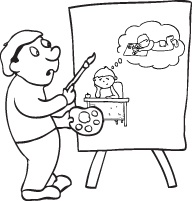

## So Long

This is it, the end. We have taught you everything we learned in our first semester, and this chapter is a bonus. Now don’t stop here; there is a lot more to learn.

As this chapter explains, the Racket language is incredibly powerful, and language creation is a ubiquitous element in the world of Racket. Search for “web server” in the Racket documentation. It comes with its own special scripting language that allows for powerful ways of interacting with users. Take a look at Slideshow, a language for creating slides for lectures and presentations. And do play with Scribble, the language in which Racketeers write their documentation and research papers. You have not seen this incredible capability for language creation before. It makes Racket more interesting than any other language you may ever encounter.

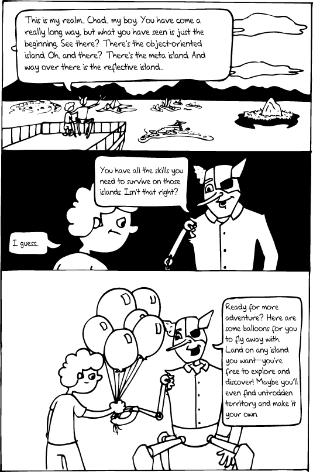

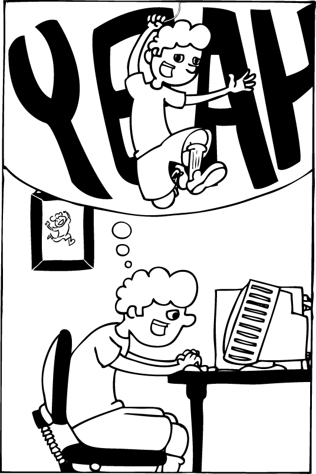

## Index

### Symbols

**#%app top level form, ).4 Racket Is a Programming-Language Programming Language, ).4 Racket Is a Programming-Language Programming Language**

**#%datum top level form, ).4 Racket Is a Programming-Language Programming Language**

**#%module-begin top level form, ).4 Racket Is a Programming-Language Programming Language**

**#%top-interaction top level form, ).4 Racket Is a Programming-Language Programming Language**

**#:mutable keyword, 8.4 Action: How Structs Really Work**

**#:opaque keyword, iworld Structures**

**#:prefab keyword, 13.1 What Is a Distributed Game?**

**#:transparent keyword, Nesting Structures**

**#:when keyword, 9.3 Back to FOR/FOLD**

**#f value, One Thing at a Time with IF**

**#lang lazy, 11.4 Racket Can Be Lazy**

**#lang racket, 1.1 Readying Racket**

**#lang racket/base, ).1 Run Racket Run**

**#lang s-exp, ).4 Racket Is a Programming-Language Programming Language**

**#t value, One Thing at a Time with IF**

**' (quote), for data, Symbols, The CONS Function**

**+force function, ).4 Racket Is a Programming-Language Programming Language**

**, (unquote), for quasiquoted lists, ).4 Racket Is a Programming-Language Programming Language**

**,@ (unquote-splicing), for quasiquoted lists, ).4 Racket Is a Programming-Language Programming Language**

**/force function, ).4 Racket Is a Programming-Language Programming Language**

**2htdp/image library, 5.1 Graphical User Interface**

**2htdp/universe library, 5.1 Graphical User Interface**

**(see also big-bang; universe)**

**= function, 4.1 How to Ask**

**` (quasiquote), for lists, ).4 Racket Is a Programming-Language Programming Language**

### A

**above function, 8.8 Rendering the Orc World**

**above/align function, 8.8 Rendering the Orc World**

**accessor, Structure Basics**

**add function, Neighbors**

**add-3-to-state function, 5.2 Landing a UFO**

**add-board-to-scene function, 10.6 Roll the Dice**

**add-dice-to function, The Game Tree**

**add-path function, The Entree State**

**add-player function, The Join State and Network Events**

**add-player-info function, 10.6 Roll the Dice**

**add-players function, The Entree State**

**add-progress-bar function, The Appetizer State**

**add-spectator function, The Play State and Network Events**

**add-territory function, 10.7 Rendering the Dice World**

**add-waypoint function, The Play State and Network Events**

**add-waypoint* function, The Entree State**

**add1 function, Functions for Closing In**

**age-goo function, Rotting Goo**

**AI (artificial intelligence), Controlling the Game, (Artificial Intelligence)**

**ALGOL, (.2 Where Did Lisp Come From?**

**all-but-last function, Slithering**

**all-dead? function, 8.9 The End of the World**

**all-monsters-attack-player function, 8.10 Actions, A Final Look**

**and form, 4.3 Cool Tricks with Conditionals**

**andmap function, 7.3 Higher-Order Fun**

**app structure, State of Henry**

**apply function, 7.5 Derive This!**

**argmax function, 12.3 Adding Artificial Intelligence**

**arrange function, 8.8 Rendering the Orc World**

**artificial intelligence (AI), Controlling the Game, (Artificial Intelligence)**

**attackable? function, Neighbors**

**attacking function, 10.8 Input Handling**

### B

**bake-cupcakes function, The Join State and Tick Events**

**Barski, Conrad, i, Preface (Hello World)**

**Bayesian mathematics, ).3 Racket Is a Metaprogramming Language**

**begin form, ).3 Racket Is a Metaprogramming Language**

**beside function, 7.5 Derive This!, 8.8 Rendering the Orc World, 8.8 Rendering the Orc World**

**big-bang, 5.2 Landing a UFO, 6.3 The Main Function, 8.5 More Actions, Setting Up the World for Good, 10.5 Game States and Game Trees for Dice of Doom, State of the House**

**clauses, 5.3 Using big-bang: Syntax and Semantics**

**name, The Client, State of the House**

**on-key, 5.3 Using big-bang: Syntax and Semantics**

**on-mouse, State of the House**

**on-receive, The Client, State of the House**

**on-tick, 5.3 Using big-bang: Syntax and Semantics**

**register, The Client, State of the House**

**stop-when, 5.3 Using big-bang: Syntax and Semantics**

**to-draw, 5.3 Using big-bang: Syntax and Semantics**

**bigger function**

**for Guess My Number, Functions for Closing In**

**distributed, The Server**

**binary search, 2.1 The Guess My Number Game**

**body structure, Message Data and Structures**

**body-collide? function, The Play State and Tick Events**

**bon-appetit function, The Entree State**

**boolean=? function, 4.1 How to Ask**

**boolean? function, 4.1 How to Ask**

**Booleans, 3.2 The Building Blocks of Racket Syntax, Using the Stealth Conditionals AND and OR**

**(see also false value; true value)**

**branch, One Thing at a Time with IF**

**brigand structure, 8.3 Setting Up the World, a First Step**

**(see also monster structure)**

**broadcast function, The Join State and Tick Events**

**broadcast-universe function, The Join State and Tick Events**

**build-list function, 7.4 Two More Higher-Order Functions**

**bundle type, Packages**

### C

**C, (.2 Where Did Lisp Come From?**

**C++, (.2 Where Did Lisp Come From?**

**can-eat function**

**for Land of Lambda, 7.3 Higher-Order Fun**

**for Snake, 6.4 Clock Ticks**

**case form, 8.10 Actions, A Final Look**

**check-= function, Testing in the Real World**

**check-equal? function, 4.4 Equality Predicates, Once More**

**check-false function, Testing in the Real World**

**check-not-equal? function, Testing in the Real World**

**check-not-false function, Testing in the Real World**

**check-pred function, Testing in the Real World**

**check-true function, Testing in the Real World**

**Church, Alonzo, (.1 What Makes Lisp So Cool and Unusual?**

**circle function, The Entree State**

**class form, ).2 Racket Is a Programming Language**

**clause (see big-bang; cond form)**

**client, 13.1 What Is a Distributed Game?**

**client.rkt file, 13.5 Distributed Guess, 13.5 Distributed Guess, The Client**

**close? function, Eating and Growing**

**closure, 11.3 Memoized Computations**

**collects, 13.4 Organizing Your Universe**

**color-chooser function, 10.7 Rendering the Dice World**

**command line execution, ).1 Run Racket Run**

**comments, 3.2 The Building Blocks of Racket Syntax**

**complex numbers, Symbols, Complex Numbers Are Good Positions**

**(see also numbers)**

**composite data, 4.1 How to Ask**

**compute-every-1000th function, 11.2 Lazy Evaluation**

**cond form, One Thing at a Time with IF**

**conditionals**

**and, 4.3 Cool Tricks with Conditionals, 4.4 Equality Predicates, Once More**

**case, 8.7 Initializing the Orc World, 8.10 Actions, A Final Look**

**cond, One Thing at a Time with IF**

**if, 4.1 How to Ask**

**or, 4.3 Cool Tricks with Conditionals**

**unless, Using the Stealth Conditionals AND and OR, Variable Definitions**

**when, Using the Stealth Conditionals AND and OR, 8.10 Actions, A Final Look**

**connect clause, iworld Structures**

**connect function**

**for Guess My Number, distributed, The State of the Client and the State of the Server**

**for Hungry Henry, The Entree State**

**cons cell, CONS Cells**

**cons function, Functions for CONS Cells**

**cons? function, 6.6 Rendering**

**constant, Variable Definitions**

**count++ function, ).4 Racket Is a Programming-Language Programming Language**

**count-and-print macro, ).4 Racket Is a Programming-Language Programming Language**

**create-player function, The Join State and Network Events**

**create-world-of-dice-and-doom function, 10.5 Game States and Game Trees for Dice of Doom**

**current-target function, 8.10 Actions, A Final Look**

### D

**d/dx function, 7.5 Derive This!**

**damage-monster function, 8.10 Actions, A Final Look**

**data types (see Booleans; bundle type; iworld type; mail type; number type; package type; promise type; sequence type; string type; structures)**

**dead? function, 6.6 Rendering**

**deal-with-guess function, The Main Function**

**decrease-attack# function, 8.10 Actions, A Final Look**

**define form, 2.1 The Guess My Number Game, (define define ’define)**

**define-syntax-rule form, ).2 Racket Is a Programming Language**

**define-values form, 9.2 Multiple Values**

**define/private form, for classes, ).2 Racket Is a Programming Language**

**define/public form, for classes, ).2 Racket Is a Programming Language**

**definitions, 7.1 Functions as Values**

**(see also functions, defining)**

**constants, Variable Definitions, The Data**

**local bindings, Function Definitions**

**structures, Nested Lists, Nesting Structures, 8.4 Action: How Structs Really Work**

**definitions panel, 1.1 Readying Racket**

**delay form, 11.4 Racket Can Be Lazy**

**delayed-args-app macro, ).4 Racket Is a Programming-Language Programming Language**

**dice function, 10.9 Creating a Game Tree**

**Dice of Doom, (Dice of Doom)**

**(see also artificial intelligence (AI))**

**end of game, 10.10 The End Game**

**game trees, 10.5 Game States and Game Trees for Dice of Doom, 10.8 Input Handling**

**handling input, 10.8 Input Handling**

**neighbors, how to find, The Game Tree**

**rendering, 10.6 Roll the Dice**

**rules, 10.2 Dice of Doom, The Game**

**dice-world struct, 10.5 Game States and Game Trees for Dice of Doom**

**dir? function, Rotting Goo**

**direct-snake function, Rotting Goo**

**disconnect function, 14.7 Main, Take Server**

**display function, (The Values of Loops)**

**displayln function, 9.4 More on Loops**

**distribute function, The Game Tree**

**distributed programming, (.1 What Makes Lisp So Cool and Unusual?, (The World Is Not Enough), 13.4 Organizing Your Universe**

**domain, ).3 Racket Is a Metaprogramming Language**

**domain-specific language**

**#%app, ).4 Racket Is a Programming-Language Programming Language**

**#%module-begin, ).4 Racket Is a Programming-Language Programming Language**

**creation, ).3 Racket Is a Metaprogramming Language**

**domain, (Artificial Intelligence), ).3 Racket Is a Metaprogramming Language**

**installation, ).4 Racket Is a Programming-Language Programming Language**

**delayed-lang, ).4 Racket Is a Programming-Language Programming Language**

**silly-lang, ).4 Racket Is a Programming-Language Programming Language**

**draw-a-ufo-onto-an-empty-scene function, 5.2 Landing a UFO**

**draw-dice function, 10.7 Rendering the Dice World**

**draw-dice-world function, 10.6 Roll the Dice**

**draw-end-of-dice-world function, 10.6 Roll the Dice**

**draw-focus function, 10.7 Rendering the Dice World**

**draw-guess function, The Client**

**draw-square function, Function Definitions**

**draw-territory function, 10.7 Rendering the Dice World**

**drawing (see big-bang; images; to-draw clause)**

**drop function, 8.8 Rendering the Orc World**

**drop-client function, The Join State and Network Events**

**drop-player function, The Play State and Network Events**

**DrRacket IDE, (Getting Started)**

### E

**eat function, Eating and Growing**

**eat-all-the-things function, The Play State and Tick Events**

**eighth function, Nested Lists**

**empty value, Functions for CONS Cells**

**empty-bundle function, 14.7 Main, Take Server**

**empty-scene function, 5.2 Landing a UFO**

**empty? function, 4.1 How to Ask**

**end-game-broadcast function, The Play State and Tick Events**

**end-of-orc-battle? function, 8.6 Ready, Set, big-bang**

**end-turn function, 8.9 The End of the World**

**ENIAC, (.2 Where Did Lisp Come From?**

**entree structure, State of Henry**

**eq? function, 4.4 Equality Predicates, Once More**

**equal? function, 4.1 How to Ask, 4.4 Equality Predicates, Once More**

**equality, 4.1 How to Ask, Using Functions that Return More than Just the Truth, 8.4 Action: How Structs Really Work**

**equality predicate, 4.1 How to Ask, Using Functions that Return More than Just the Truth**

**error function, Variable Definitions**

**even-row function, Neighbors**

**even? function, 4.3 Cool Tricks with Conditionals**

**exact-integer? function, 4.1 How to Ask**

**except-out form, ).4 Racket Is a Programming-Language Programming Language**

**execute function, Attacks**

**expt function, Symbols**

### F

**false value, One Thing at a Time with IF**

**fault tolerant, The Server**

**feed-em-all function, The Play State and Tick Events**

**Felleisen, Matthias, (.4 Where Does Racket Come From?**

**field, Structure Basics**

**field selector, Structure Basics**

**fifth function, Nested Lists**

**filter function, 7.3 Higher-Order Fun**

**find-move function, 10.8 Input Handling**

**findf function, 10.8 Input Handling**

**Findler, Robby, (.4 Where Does Racket Come From?**

**first function, The LIST Function**

**flail function, 8.10 Actions, A Final Look**

**flame-thrower wielding squirrels, Delay—Chapter Checkpoint**

**Flatt, Matthew, (.4 Where Does Racket Come From?**

**foldr function, 7.3 Higher-Order Fun**

**for form, (The Values of Loops)**

**for*/list, 9.4 More on Loops**

**for/and, 9.4 More on Loops**

**for/first, 9.4 More on Loops**

**for/fold, 9.1 FOR Loops, 9.2 Multiple Values**

**for/last, 9.4 More on Loops**

**for/list, 9.1 FOR Loops**

**for/or, 9.4 More on Loops**

**for-each function, 8.10 Actions, A Final Look**

**force function, 11.4 Racket Can Be Lazy**

**force* function, ).4 Racket Is a Programming-Language Programming Language**

**form, One Thing at a Time with IF**

**FORTRAN, (.2 Where Did Lisp Come From?**

**fourth function, Nested Lists**

**fresh-goo function, Rotting Goo**

**Friedman, Dan, (.4 Where Does Racket Come From?**

**functional programming, 8.3 Setting Up the World, a First Step, 10.9 Creating a Game Tree**

**functions**

**anonymous, 7.1 Functions as Values**

**calling, 1.1 Readying Racket, 2.4 Defining Functions in Racket**

**defining, 2.2 Defining Variables**

**helper, Rotting Goo, 8.8 Rendering the Orc World, 14.6 Main, Take Client**

**higher-order, 7.1 Functions as Values, 7.5 Derive This!**

**recursive, The Special Form that Does It All: COND, 6.4 Clock Ticks, Slithering**

### G

**game structure**

**for AI, 12.2 Lazy Games**

**for Dice of Doom, 10.5 Game States and Game Trees for Dice of Doom**

**game tree, Controlling the Game**

**(see also minimax)**

**branches, 10.4 How Game Trees Work**

**depth limit, 12.2 Lazy Games**

**pruning, 12.3 Adding Artificial Intelligence**

**game-tree function**

**for AI, 12.2 Lazy Games**

**for Dice of Doom, The Game Tree**

**games**

**Dice of Doom, (Dice of Doom)**

**AI, 12.2 Lazy Games**

**Guess My Number, (A First Racket Program)**

**distributed, 13.4 Organizing Your Universe**

**GUI, 5.4 Guessing Gooey**

**Hungry Henry, 14.1 King Henry the Hungry**

**Orc Battle, 8.2 Orc Battle**

**Snake, (Recursion Is Easy)**

**gensym function, The Join State and Network Events**

**get-dice-img function, 10.7 Rendering the Dice World**

**get-iws function, The Join State and Tick Events**

**get-posns-from-goo function**

**for Land of Lambda, 7.1 Functions as Values**

**for Snake, 6.6 Rendering**

**get-random-numbers function, Kill—Chapter Checkpoint**

**get-row function, 10.9 Creating a Game Tree**

**get-score function, The Play State and Tick Events**

**get-x function, 10.9 Creating a Game Tree**

**get-y function, 10.9 Creating a Game Tree**

**give-monster-turn-if-attack#=0 function, 8.10 Actions, A Final Look**

**goo structure, 6.2 A Data Representation for the Snake Game**

**goo-list+scene function**

**for Land of Lambda, 7.1 Functions as Values**

**for Snake, 6.6 Rendering**

**goto function, The Play State and Network Events**

**graphical user interface (GUI), (big-bang)**

**(see also big-bang)**

**grow function, Eating and Growing**

**guess function**

**for Guess My Number, 2.4 Defining Functions in Racket**

**distributed, The Server**

**GUI, Key-Events**

**Guess My Number, (A First Racket Program)**

**distributed, 13.4 Organizing Your Universe**

**GUI, 5.4 Guessing Gooey**

**GUI (graphical user interface), (big-bang)**

**(see also big-bang)**

### H

**handle-appetizer-message function, The Appetizer State**

**handle-entree-message function, The Entree State**

**handle-goto-message function, 14.7 Main, Take Server**

**handle-keys function, The Client**

**handle-msg function**

**for client, The Client**

**for server, The Server**

**handle-server-messages function, 14.6 Main, Take Client**

**handler function (see big-bang; universe)**

**heal function, 8.9 The End of the World**

**hexagon function, 10.7 Rendering the Dice World**

**higher-order functions, 7.1 Functions as Values**

**higher-order programming (see functions; higher-order functions; loops; memoization)**

**Hudak, Paul, (.4 Where Does Racket Come From?**

**Hungry Henry, (Hungry Henry)**

**appetizer, State of Henry, 14.6 Main, Take Client**

**entree, State of Henry, The Appetizer State**

**join, State of Henry, The Join State and Network Events**

**play, State of Henry, The Join State and Tick Events**

**hydra structure, 8.3 Setting Up the World, a First Step**

**(see also monster structure)**

### I

**IDE (interactive development environment), (Getting Started)**

**(see also DrRacket IDE)**

**if form, 4.1 How to Ask**

**image? function, 4.1 How to Ask**

**images (see above function; above/align function; beside function; circle function; empty-scene function)**

**img+scene function, 6.6 Rendering**

**img-list+scene function, 6.6 Rendering, 7.3 Higher-Order Fun**

**in-list function, 9.4 More on Loops**

**in-naturals function, 11.2 Lazy Evaluation**

**in-range function, 9.4 More on Loops**

**Indiana University, (.4 Where Does Racket Come From?**

**inherit-field form, for classes, ).2 Racket Is a Programming Language**

**init-field form, for classes, ).2 Racket Is a Programming Language**

**initialize-monsters function, 8.7 Initializing the Orc World**

**initialize-orc-world function, 8.6 Ready, Set, big-bang**

**initialize-player function, 8.7 Initializing the Orc World**

**inside-of-rectangle? function, Function Definitions**

**instance, Structure Basics**

**instructions function, 8.8 Rendering the Orc World**

**integer? function, 4.1 How to Ask**

**interact-count-and-print macro, ).4 Racket Is a Programming-Language Programming Language**

**interact-with-board function, 10.6 Roll the Dice**

**interactions panel, 1.1 Readying Racket**

**interactive development environment (IDE), (Getting Started)**

**(see also DrRacket IDE)**

**interval structure, The Data**

**ip structure, State of the House**

**iworld type, Packages**

**iworld-name function, 14.3 Two United States**

**iworld=? function, iworld Structures**

### J

**join structure, State of Henry**

**join-add-player function, The Join State and Network Events**

**join-remove function, The Join State and Network Events**

### K

**keep-waiting function, The Join State and Tick Events**

**keep-waiting? function, The Join State and Tick Events**

**key=? function, The Main Function**

**keyword, 2.1 The Guess My Number Game**

**Krishnamurthi, Shriram, (.4 Where Does Racket Come From?**

### L

**lambda, (Land of Lambda)**

**(see also closure)**

**lambda form, 7.1 Functions as Values, 7.5 Derive This!**

**Land of Lisp, i, Preface (Hello World)**

**launch-guess-client function, The Client**

**launch-guess-server function, The State of the Client and the State of the Server**

**lazy evaluation, 11.1 Doomsday**

**(see also memoization)**

**delay, 11.4 Racket Can Be Lazy, 12.2 Lazy Games**

**force, 11.4 Racket Can Be Lazy, 12.2 Lazy Games**

**left function, 10.8 Input Handling**

**length function, 8.10 Actions, A Final Look**

**let form, 8.4 Action: How Structs Really Work**

**lets-eat function, State of the House**

**Lisp language, i, Introduction (Open Paren)**

**list function, Strings**

**list-eater, The Special Form that Does It All: COND**

**list-ref function, 8.8 Rendering the Orc World**

**list? function, 4.1 How to Ask**

**lists, (The Values of Loops)**

**(see also for form)**

**cons, Functions for CONS Cells**

**cons cell, CONS Cells**

**empty, Functions for CONS Cells**

**first, Functions for CONS Cells, The LIST Function**

**for/list, 9.1 FOR Loops**

**list-eaters, The Special Form that Does It All: COND**

**loop functions**

**andmap, 7.3 Higher-Order Fun**

**filter, 7.2 Lambda**

**foldl, 7.3 Higher-Order Fun**

**foldr, 7.3 Higher-Order Fun**

**map, 7.1 Functions as Values**

**ormap, 7.3 Higher-Order Fun**

**rest, Functions for CONS Cells, The LIST Function**

**traversals (see for form; list-eater; lists; loop functions; loops; recursion)**

**local definitions**

**of constants, Function Definitions**

**of functions, 4½.2 Local Definitions**

**LOCALHOST constant, iworld Structures**

**loop functions**

**andmap, 7.3 Higher-Order Fun**

**filter, 7.2 Lambda**

**foldl, 7.3 Higher-Order Fun**

**foldr, 7.3 Higher-Order Fun**

**map, 7.1 Functions as Values**

**ormap, 7.3 Higher-Order Fun**

**loops, (The Values of Loops)**

**(see also for form)**

**in-naturals, 11.2 Lazy Evaluation**

**in-range, 9.4 More on Loops**

**lose? function, 8.8 Rendering the Orc World**

### M

**macro programming, ).2 Racket Is a Programming Language**

**macros, ).4 Racket Is a Programming-Language Programming Language**

**(see also domain-specific language)**

**for languages, ).4 Racket Is a Programming-Language Programming Language**

**gensym, The Join State and Network Events, ).3 Racket Is a Metaprogramming Language**

**mail type, Packages**

**main functions, Functions for Closing In**

**make-bundle function, Packages**

**make-connection function, The Join State and Network Events**

**make-lazy+ function, 11.2 Lazy Evaluation**

**make-mail function, Packages**

**make-object function, ).2 Racket Is a Programming Language**

**make-package function, Packages**

**make-rectangular function, Complex Numbers Are Good Positions**

**map function, 7.3 Higher-Order Fun**

**mark function, 10.8 Input Handling**

**max function, Functions for Closing In**

**member function, Using Functions that Return More than Just the Truth**

**memoization, 11.2 Lazy Evaluation**

**memoize function, 11.2 Lazy Evaluation**

**memoize.v2 function, 11.3 Memoized Computations**

**message function, 8.8 Rendering the Orc World**

**metaprogramming (see domain-specific language; macro programming)**

**minimax, 12.2 Lazy Games**

**MIT, (.2 Where Did Lisp Come From?**

**module, (define define ’define), 13.4 Organizing Your Universe**

**module-level definitions, (define define ’define)**

**monster structure, 8.7 Initializing the Orc World**

**monster-alive? function, 8.9 The End of the World**

**move structure, 10.5 Game States and Game Trees for Dice of Doom**

**move-and-eat function, The Play State and Network Events**

**move-player* function, The Play State and Network Events**

**move-target function, 8.10 Actions, A Final Look**

**move-toward-waypoint function, The Play State and Tick Events**

**mutate, 8.3 Setting Up the World, a First Step**

**mutator, 8.4 Action: How Structs Really Work**

**my-and function, ).2 Racket Is a Programming Language**

**my-andmap function, 7.3 Higher-Order Fun**

**my-build-list function, 7.4 Two More Higher-Order Functions**

**my-equal? function, 4.4 Equality Predicates, Once More**

**my-filter function, 7.2 Lambda**

**my-first-program.rkt file, 1.2 Interacting with Racket**

**my-foldl function, 7.3 Higher-Order Fun, 7.4 Two More Higher-Order Functions**

**my-if function, So Long**

**my-let.v1 macro, ).3 Racket Is a Metaprogramming Language**

**my-map function, 7.1 Functions as Values**

**my-or macro, ).3 Racket Is a Metaprogramming Language**

**my-ormap function, 7.3 Higher-Order Fun**

### N

**name clause, The Client**

**named-player function, The Join State and Network Events**

**neighbors function, Neighbors**

**new form, ).2 Racket Is a Programming Language**

**next-head function, Slithering**

**next-interval function, The Server**

**next-pit function, 6.3 The Main Function**

**ninth function, Nested Lists**

**no-more-moves-in-world? function, 10.6 Roll the Dice**

**number type**

**complex, Symbols, Complex Numbers Are Good Positions**

**exact, Symbols**

**floating-point, Symbols**

**inexact, Numbers**

**integer, Symbols**

**natural, 4½.2 Local Definitions, 7.4 Two More Higher-Order Functions, 11.2 Lazy Evaluation**

**rational, Symbols**

**real, Complex Numbers Are Good Positions**

**number->string function, Key-Events**

**number? function, 4.1 How to Ask**

### O

**object% value, ).2 Racket Is a Programming Language**

**object-oriented language, ).2 Racket Is a Programming Language**

**object-oriented programming**

**classes, ).2 Racket Is a Programming Language**

**classes as values, ).2 Racket Is a Programming Language**

**methods, ).1 Run Racket Run**

**objects, ).2 Racket Is a Programming Language**

**odd-row function, Neighbors**

**odd? function, 4.3 Cool Tricks with Conditionals**

**on-key clause, 5.3 Using big-bang: Syntax and Semantics**

**on-msg clause, iworld Structures**

**on-new clause, iworld Structures**

**on-receive clause, iworld Structures**

**on-tick clause, 5.3 Using big-bang: Syntax and Semantics**

**only-in function, The Play State and Tick Events**

**opposite-dir? function, 6.5 Key-Events**

**or form, 4.3 Cool Tricks with Conditionals**

**Orc Battle, 8.2 Orc Battle**

**actions, 8.3 Setting Up the World, a First Step, 8.9 The End of the World**

**ending game, 8.8 Rendering the Orc World**

**orc world**

**initializing, 8.7 Initializing the Orc World**

**rendering, 8.8 Rendering the Orc World**

**setting up the world, 8.2 Orc Battle**

**starting game, 8.5 More Actions, Setting Up the World for Good**

**orc structure, 8.3 Setting Up the World, a First Step**

**(see also monster structure)**

**orc-world structure, 8.5 More Actions, Setting Up the World for Good**

**ormap function, 7.3 Higher-Order Fun**

**overlay function, Key-Events, 6.6 Rendering**

**overlay/align function, 8.8 Rendering the Orc World**

**overlay/offset function, 10.7 Rendering the Dice World**

### P

**package type, Packages**

**Pascal, (.2 Where Did Lisp Come From?**

**pass function**

**for AI, 12.3 Adding Artificial Intelligence**

**for Dice of Doom, 10.8 Input Handling**

**PDE (program development environment), (Getting Started)**

**pit structure, 6.1 Robot Snake**

**place-image function, Function Definitions**

**place-image/align function, The Data**

**play structure, State of Henry**

**play-add-spectator function, The Play State and Network Events**

**player structure**

**for Hungry Henry, Message Data and Structures**

**for Orc Battle, 8.4 Action: How Structs Really Work**

**player-acts-on-monsters function, 8.6 Ready, Set, big-bang**

**player-dead? function, 8.8 Rendering the Orc World**

**player-health+ function, 8.4 Action: How Structs Really Work**

**player-remove function, The Play State and Network Events**

**player-update! function, 8.4 Action: How Structs Really Work**

**posn structure, 6.1 Robot Snake**

**posn-move function, Slithering**

**posn=? function, 6.7 End Game**

**predicate, (Conditions and Decisions)**

**prefab (previously fabricated structure), 13.1 What Is a Distributed Game?**

**program development environment (PDE), (Getting Started)**

**progress function, The Play State and Tick Events**

**promise type, 11.4 Racket Can Be Lazy**

**provide form, 13.4 Organizing Your Universe**

### Q

**quasiquote (`), for lists, ).4 Racket Is a Programming-Language Programming Language**

**quote ('), for data, Symbols, The CONS Function**

### R

**Racket, i**

**conventions, 2.2 Defining Variables, 3.2 The Building Blocks of Racket Syntax, 4.1 How to Ask, The Special Form that Does It All: COND**

**download, 1.1 Readying Racket**

**etiquette, 2.2 Defining Variables**

**history, (.1 What Makes Lisp So Cool and Unusual?**

**racket-lang.org, 1.1 Readying Racket**

**racket/promise library, 11.4 Racket Can Be Lazy**

**Racketeer, 1.1 Readying Racket**

**rackunit library, 4.4 Equality Predicates, Once More**

**raco, ).1 Run Racket Run**

**random+ function, 8.7 Initializing the Orc World**

**random-number-of-attacks function, 8.7 Initializing the Orc World**

**random-quotient function, 8.7 Initializing the Orc World**

**random-stars function, Function Definitions**

**rate-moves function, 12.3 Adding Artificial Intelligence**

**rate-position function, 12.3 Adding Artificial Intelligence**

**rational? function, 4.1 How to Ask**

**read-eval-print loop, 1.1 Readying Racket**

**reader, 3.2 The Building Blocks of Racket Syntax**

**real-part function, Complex Numbers Are Good Positions**

**real? function, 4.1 How to Ask**

**rectangle function, 8.8 Rendering the Orc World**

**recursion, The Special Form that Does It All: COND**

**refocus-board function, 10.8 Input Handling**

**register clause, iworld Structures**

**remainder function, 11.2 Lazy Evaluation**

**remake-join function, The Play State and Tick Events**

**remove function, Eating and Growing**

**rename-out form, ).4 Racket Is a Programming-Language Programming Language**

**render function, Key-Events**

**render-appetizer function, 14.6 Main, Take Client**

**render-avatar function, The Entree State**

**render-end function, 6.6 Rendering**

**render-entree function, The Appetizer State**

**render-id+image function, The Appetizer State**

**render-last-scene function, Key-Events**

**render-monsters function, 8.8 Rendering the Orc World**

**render-orc-battle function, 8.6 Ready, Set, big-bang**

**render-orc-world function, 8.8 Rendering the Orc World**

**render-pit function, 6.5 Key-Events**

**render-player function, 8.8 Rendering the Orc World**

**render-scores function, The Entree State**

**render-text function, The Entree State**

**render-the-end function, 8.6 Ready, Set, big-bang**

**render-the-meal function, 14.6 Main, Take Client**

**renew function**

**for Land of Lambda, 7.3 Higher-Order Fun**

**for Snake, Rotting Goo**

**require form, 4.4 Equality Predicates, Once More, 13.4 Organizing Your Universe**

**rest function, The LIST Function**

**restart function, The Entree State**

**return-five function, A Function for Guessing**

**Rice University, (.4 Where Does Racket Come From?**

**right function, 10.8 Input Handling**

**rip function, The Join State and Network Events**

**roll-the-dice function, 10.5 Game States and Game Trees for Dice of Doom**

**rot function**

**for Land of Lambda, 7.1 Functions as Values**

**for Snake, Rotting Goo**

**rotate-until function, 10.8 Input Handling**

**rotten? function, Rotting Goo**

**run function, Running the Game**

**run.rkt file, Running the Game**

### S

**S-expression type, 13.1 What Is a Distributed Game?**

**scope, Function Definitions**

**score function, The Play State and Tick Events**

**second function, Nested Lists**

**selector (see field selector)**

**self-colliding? function, 6.6 Rendering**

**semantics, (Basics of Racket), 3.2 The Building Blocks of Racket Syntax**

**sequence type, 9.4 More on Loops**

**serialize-universe function, The Join State and Tick Events**

**serve-dinner function, The Play State and Tick Events**

**server, 13.1 What Is a Distributed Game?**

**server.rkt file, 13.5 Distributed Guess, The State of the Client and the State of the Server**

**set! form, A Function for Guessing**

**set-waypoint function, 14.6 Main, Take Client**

**seventh function, Nested Lists**

**shared.rkt file, 13.5 Distributed Guess**

**single? function**

**for Guess My Number, distributed, The Server**

**for Guess My Number, GUI, Key-Events**

**sixth function, Nested Lists**

**slime structure, 8.3 Setting Up the World, a First Step**

**(see also monster structure)**

**slither function, Eating and Growing**

**smaller function**

**for Guess My Number, A Function for Guessing**

**distributed, The Server**

**GUI, The Main Function**

**Snake, (Recursion Is Easy)**

**data representation, 6.1 Robot Snake**

**ending game, 6.6 Rendering**

**functions in, 6.3 The Main Function, 6.7 End Game**

**snake structure, 6.1 Robot Snake**

**snake%, ).2 Racket Is a Programming Language**

**snake+scene function, 6.5 Key-Events**

**snake-body function, 6.7 End Game**

**snake-change-dir function, 6.7 End Game**

**snake-head function, 6.7 End Game**

**snake-tail function, 6.7 End Game**

**sort function, The Entree State**

**sqrt function, Symbols**

**square function, 3.2 The Building Blocks of Racket Syntax**

**squirrels, flame-thrower wielding, Delay—Chapter Checkpoint**

**stab function, 8.9 The End of the World**

**start function**

**for Guess My Number, Functions for Closing In**

**GUI, The Data**

**for Orc Battle, 8.5 More Actions, Setting Up the World for Good**

**start-game function, The Join State and Tick Events**

**start-snake function, 6.3 The Main Function**

**state machine, 14.1 King Henry the Hungry**

**state-is-300 function, 5.2 Landing a UFO**

**status-bar function, 8.8 Rendering the Orc World**

**Steele, Guy, (.4 Where Does Racket Come From?**

**stop-when clause, 5.3 Using big-bang: Syntax and Semantics**

**stop-with function, The Main Function**

**stream type, 9.4 More on Loops**

**string type, Numbers**

**string-append function, Strings**

**string=? function, 4.1 How to Ask**

**string? function, 4.1 How to Ask**

**struct form, Nested Lists**

**struct inheritance, 8.3 Setting Up the World, a First Step**

**struct-out form, 13.4 Organizing Your Universe**

**structures, 7.1 Functions as Values**

**(see also definitions, structures)**

**creating, Nested Lists**

**field access, Structure Basics**

**mutation, 8.3 Setting Up the World, a First Step**

**predicates, 4.1 How to Ask**

**sub1 function, Functions for Closing In**

**sum-territory function, 10.10 The End Game**

**super-new form, for classes, ).2 Racket Is a Programming Language**

**suspended computation, 11.1 Doomsday**

**Sussman, Gerry, (.4 Where Does Racket Come From?**

**switch function, The Game Tree**

**switch-to-entree function, The Appetizer State**

**symbol type, Symbols**

**symbol=? function, 4.1 How to Ask, 4.1 How to Ask**

**symbol? function, 4.1 How to Ask**

**syntax, (Basics of Racket)**

**(see also comments; conditionals; define form; form)**

**begin, ).3 Racket Is a Metaprogramming Language, ).4 Racket Is a Programming-Language Programming Language**

**let, 8.4 Action: How Structs Really Work, 12.2 Lazy Games, State of the House, ).3 Racket Is a Metaprogramming Language**

**set!, A Function for Guessing, 4.3 Cool Tricks with Conditionals, 11.2 Lazy Evaluation**

**syntax error, 3.1 Syntax and Semantics**

### T

**take function, 8.8 Rendering the Orc World**

**teaching languages, 1.1 Readying Racket**

**tenth function, Nested Lists**

**territory structure, 10.5 Game States and Game Trees for Dice of Doom**

**territory-build function, 10.8 Input Handling**

**test expression, in if expression, One Thing at a Time with IF**

**testing, 4.4 Equality Predicates, Once More**

**text function, The Data, 6.6 Rendering, 8.8 Rendering the Orc World**

**the-ai-plays function, 12.3 Adding Artificial Intelligence**

**then expression, in if expression, One Thing at a Time with IF**

**third function, Nested Lists**

**thunk, 11.1 Doomsday**

**tick ('), for data, Symbols, The CONS Function**

**tick-tock function, 14.7 Main, Take Server**

**time-broadcast function, The Join State and Tick Events**

**time? function, The Appetizer State**

**to-draw clause, 5.3 Using big-bang: Syntax and Semantics**

**true value, One Thing at a Time with IF**

**Turing, Alan, 3.1 Syntax and Semantics**

**type predicate, 4.1 How to Ask**

### U

**universe, 13.1 What Is a Distributed Game?, The Entree State**

**clauses, iworld Structures**

**on-disconnect, The Entree State**

**on-msg, The State of the Client and the State of the Server, The Entree State**

**on-new, The State of the Client and the State of the Server, The Entree State**

**on-tick, The Entree State**

**universe form, 13.1 What Is a Distributed Game?**

**unless form, Using the Stealth Conditionals AND and OR**

**unmark function, 10.8 Input Handling**

### V

**values form, 9.1 FOR Loops**

**variable bindings, 9.1 FOR Loops**

**view, 5.1 Graphical User Interface**

**void function, 8.4 Action: How Structs Really Work**

### W

**wait-or-play function, The Join State and Tick Events**

**wall-colliding? function, 6.7 End Game**

**when form, Using the Stealth Conditionals AND and OR**

**win? function, 8.8 Rendering the Orc World**

**winners function**

**for Dice of Doom, 10.10 The End Game**

**won function, 10.10 The End Game**

**world-change-dir function, Rotting Goo**

**worlds, 5.1 Graphical User Interface**

### Z

**zero? function, 4.1 How to Ask**

## About the Authors

Professor Matthias Felleisen is one of the original authors of the Racket language and a co-author of *The Little Schemer* and *How to Design Programs*. In 1995, Felleisen launched the TeachScheme! Project, reaching out to high schools with a radically novel computing curriculum. Felleisen is the 2012 recipient of the ACM Special Interest Group on Programming Languages (SIGPLAN) Lifetime Achievement Award as well as ACM's 2009 Karl V. Karlstrom Outstanding Educator Award. He is currently a Trustee Professor in the College of Computer and Information Science at Northeastern University in Boston, Massachusetts.

Conrad Barski has an M.D. from the University of Miami and nearly 20 years of programming experience. The author of *Land of Lisp*, Barski is also an avid cartoonist, having created the popular alien Lisp mascot and many graphical tutorials.

David Van Horn is a research professor who has programmed in Racket and Scheme for over a decade.

Eight students of Northeastern University contributed to Realm of Racket: Forrest Bice, Rose DeMaio, Spencer Florence, Feng-Yun Mimi Lin, Scott Lindeman, Nicole Nussbaum, Eric Peterson, and Ryan Plessner.

# Realm of Racket: Learn to Program, One Game at a Time!

Matthias Felleisen

Conrad Barski M.D.

David Van Horn

Eight Students of Northeastern University

Copyright © 2013

**REALM OF RACKET.** Copyright © 2013 by Matthias Felleisen, David Van Horn, Conrad Barski, M.D., Forrest Bice, Rose DeMaio, Spencer Florence, Feng-Yun Mimi Lin, Scott Lindeman, Nicole Nussbaum, Eric Peterson, Ryan Plessner.

All rights reserved. No part of this work may be reproduced or transmitted in any form or by any means, electronic or mechanical, including photocopying, recording, or by any information storage or retrieval system, without the prior written permission of the copyright owner and the publisher.

17 16 15 14 13 1 2 3 4 5 6 7 8 9

ISBN-10: 1-59327-491-2

ISBN-13: 978-1-59327-491-7

Publisher: William Pollock  
Production Editor: Alison Law  
Cover Illustration: Eric Peterson  
Illustrations: Feng-Yun Mimi Lin and Eric Peterson  
Interior Design and Composition: Rose DeMaio and Nicole Nussbaum  
Developmental Editors: Keith Fancher and William Pollock  
Copyeditor: Marilyn Smith  
Proofreader: Paula L. Fleming

*Library of Congress Cataloging-in-Publication Data:*

Felleisen, Matthias.

Realm of Racket : learn to program, one game at a time! / by Matthias Felleisen, Conrad Barski, Forrest Bice, Rose DeMaio, Spencer Florence, Feng-yun Mimi Lin, Scott Lindeman, Nicole Nussbaum, Eric Peterson, Ryan Plessner, and David Van Horn.

pages cm

Includes index.

ISBN-13: 978-1-59327-491-7

ISBN-10: 1-59327-491-2

1. Racket (Computer program language) 2. LISP (Computer program language) 3. Computer programming. I. Title.

QA76.73.R33F45 2013

005.1--dc23

2013002308

No Starch Press and the No Starch Press logo are registered trademarks of No Starch Press, Inc. Other product and company names mentioned herein may be the trademarks of their respective owners. Rather than use a trademark symbol with every occurrence of a trademarked name, we are using the names only in an editorial fashion and to the benefit of the trademark owner, with no intention of infringement of the trademark.

The information in this book is distributed on an “As Is” basis, without warranty. While every precaution has been taken in the preparation of this work, neither the author nor No Starch Press, Inc. shall have any liability to any person or entity with respect to any loss or damage caused or alleged to be caused directly or indirectly by the information contained in it.

No Starch Press

2013-07-10T12:09:51-07:00